**CS4132 Data Analytics**

# Analysis of live streaming of games on Twitch and Youtube by Lim Cheng Ian

Important Note: Please keep your report concise and relevant (i.e. show only relevant steps and visualizations used to answer your research questions).

# Table of Content (with relevant hyperlinks to sections)

- Motivation & Background
- Summary of Questions and Results
- Dataset
- Methodology
  - Data Acquisition
  - Data Cleaning
  - EDA
    - Q1. How has the popularity of these platforms changed over time?
    - Q2. How has the distribution of views changed over time?
    - Q3. How has the proportion of gaming content changed for each site?
    - Q4. What are the top few games on each platform, and how has their stream time changed?
    - Q5. What is the relationship between the stream time and the number of followers gained for Twitch streamers?
- Results Findings & Conclusion
- Recommendations or Further Works
- References

# Motivation and Background

Give an overview of the project, motivation, background and goals.

In recent years, live streaming has emerged globally due to the internet, with many people in the world today either consuming such content, or are creating it themselves, through various live streaming platforms. Two of these platforms, Twitch and Youtube, have grown to become large content hubs, covering millions of hours of content and many viewers. Twitch, especially, is a content hub focused on the live streaming of games. In this project, I aim to analyze the popularity of these platforms, the changing viewership of live streaming content creators on these platforms (also called 'live streamers'), as well as the content of those streams.

# Summary of Research Questions & Results

Repeat your research questions in a numbered list. After each research question, clearly state the answer/conclusion you determined. Do not give details or justifications yet — just the answer

1. How has the popularity of these platforms changed over time?
- The popularity of Youtube is slightly decreasing, while Twitch's popularity has increased and has been more or less stable over the past year.
1. How has the distribution of views changed over time?
- The distribution for the number of views per stream on Youtube is becoming more clustered, with its mode having increased from past years, while the views gained per month for top streamers has its distribution gradually spreading, and the mode of the views gained consistently increasing.
1. How has the proportion of gaming content changed for each site?
- Twitch has a large percentage of streams being games. However, Youtube's percentage is low and this percentage is on a decreasing trend for both of these platforms, although the effect is not very pronounced on Twitch.
1. What are the top few games on each platform, and how has their stream time changed?
- The most streamed game on Youtube would be League of Legends, and Fortnite for Twitch. However, the stream time for games on Youtube is on a decreasing trend, with a sharp spike in July 2022, while it is on a slight increasing trend for Twitch with some stagnation in the past year.
1. What is the relationship between the stream time and the number of followers gained for Twitch streamers?
- There is no correlation between the stream time and the followers gained.

# Dataset

Numbered list of dataset (with downloadable links) and a brief but clear description of each dataset used. Draw reference to the numbering when describing methodology (data cleaning and analysis).

1. https://trends.google.com/trends/explore?date=all&q=%2Fm%2F09jcvs,%2Fm%2F0hgpf7h This data contains the amount of searches for Youtube and Twitch.
2. https://sullygnome.com/games/watched This data contains the games streamed on Twitch. To obtain my data, this data is filtered and analysed by month, where corresponing sets of 100 entries are downloaded.
3. https://sullygnome.com/channels/watched This data contains the streamers on Twitch. The data obtaining process is the same as above, where entries are repeatedly downloaded, until January 2016 where the data ends. The data only shows for the 1st 5100 entries.
4. https://developers.google.com/youtube/v3/docs/search/list This is just the documentation for querying the livestreams from youtube via its api.
5. https://developers.google.com/youtube/v3/docs/videos/list To get further information on the Youtube video, the results from the function above has to be cleaned and fed into this function, which allows us to view the genres of the video. (To get the game name, it can simply be webscraped off of youtube using the videoid already obtained.)
6. https://developers.google.com/youtube/v3/docs/videoCategories/list To get further information on the video categories, we can query through this, to get data on how the category id corresponds to each category.

# Methodology

You should demonstrate the data science life cycle here (from data acquisition to cleaning to EDA and analysis etc).

```python
#necessary imports
import pandas as pd
import numpy as np
import os
import ast
import seaborn as sns
import matplotlib.pyplot as plt
import joypy
from matplotlib import cm
import datetime as dt
from sklearn.linear_model import LinearRegression
from sklearn.model_selection import train_test_split
```

## Data Acquisition

Display the data which will be used in the project. The data should be saved in .xlsx or .csv format to be submitted with the project. If webscraping has been done to obtain your data, save your webscraping code in another jupyter notebook as appendix to be submitted separately from the report. Import and display each dataset in a dataframe. For each dataset, give a brief overview of the data it contains, and explain the meaning of columns that are relevant to the project.

### General

For analysing site popularity data, we can just download it from google trends.

```python
a_trend = pd.read_csv('streaming_search_results/all_trend.csv')
a_trend
```

|  | Month | Twitch: (Worldwide) | YouTube: (Worldwide) |
| --- | --- | --- | --- |
| 0 | 2004-01 | <1 | <1 |
| 1 | 2004-02 | <1 | <1 |
| 2 | 2004-03 | <1 | <1 |
| 3 | 2004-04 | <1 | <1 |
| 4 | 2004-05 | <1 | <1 |
| ... | ... | ... | ... |
| 220 | 2022-05 | 2 | 36 |
| 221 | 2022-06 | 2 | 36 |
| 222 | 2022-07 | 2 | 36 |
| 223 | 2022-08 | 2 | 36 |
| 224 | 2022-09 | 2 | 36 |

225 rows × 3 columns

```python
t_trend = pd.read_csv('streaming_search_results/t_trend.csv')
t_trend
```

|  | Month | Twitch: (Worldwide) |
| --- | --- | --- |
| 0 | 2004-01 | <1 |
| 1 | 2004-02 | <1 |
| 2 | 2004-03 | 1 |
| 3 | 2004-04 | <1 |
| 4 | 2004-05 | <1 |
| ... | ... | ... |
| 220 | 2022-05 | 85 |
| 221 | 2022-06 | 84 |
| 222 | 2022-07 | 88 |
| 223 | 2022-08 | 86 |
| 224 | 2022-09 | 81 |

225 rows × 2 columns

### Youtube

The original youtube dataset is obtained by repeatedly querying youtube through the youtube API and obtaining results. This data is queried per day, so there are around ~2500 files, all of which will not be displayed.

The code to obtain this dataset can be found in the appendix, although the api keys to query the data from have been suspended by google, so it is no longer working.

```python
#some sample youtube data
pd.read_excel('yt_vids/yt_vid_20150828.xlsx').head()
```

|  | kind | etag | id | snippet |
| --- | --- | --- | --- | --- |
| 0 | youtube#searchResult | 6-Ylc3f261Si7WqdN4-78qR8uTM | {'kind': 'youtube#video', 'videoId': 'fIvf4OfM... | {'publishedAt': '2015-08-28T21:27:55Z', 'chann... |
| 1 | youtube#searchResult | f_FH3pq8zSI-Kb3gFbO9aaAKBxo | {'kind': 'youtube#video', 'videoId': 'mpMD0t-v... | {'publishedAt': '2015-08-28T20:50:54Z', 'chann... |
| 2 | youtube#searchResult | u14x7xMBCayTSMhAr88Uw3OWfJo | {'kind': 'youtube#video', 'videoId': '1EMyr0fE... | {'publishedAt': '2015-08-28T00:35:50Z', 'chann... |
| 3 | youtube#searchResult | 7wp5u_DZpDqlK3EqBortINHh6iQ | {'kind': 'youtube#video', 'videoId': '1CHlzDOz... | {'publishedAt': '2015-08-28T19:43:41Z', 'chann... |
| 4 | youtube#searchResult | DlefDXEYBabfqq34zDQAZevhM8o | {'kind': 'youtube#video', 'videoId': 'TzfNwuuI... | {'publishedAt': '2015-08-28T14:44:36Z', 'chann... |

```python
pd.read_excel('yt_vids/yt_vid_20220603.xlsx').head()
```

|  | kind | etag | id | snippet |
| --- | --- | --- | --- | --- |
| 0 | youtube#searchResult | 55sdPAzxRaL1XIbZPE934WPdGNw | {'kind': 'youtube#video', 'videoId': 'xKFHPG6c... | {'publishedAt': '2022-06-03T12:10:04Z', 'chann... |
| 1 | youtube#searchResult | O2Z1YnMOEZRxTdZq4oT4w67kly4 | {'kind': 'youtube#video', 'videoId': 'Pr2IYgnx... | {'publishedAt': '2022-06-03T11:46:47Z', 'chann... |
| 2 | youtube#searchResult | 8J98jzRR8hxVLdNmVDjMldTWY-g | {'kind': 'youtube#video', 'videoId': 'OVUIf0tC... | {'publishedAt': '2022-06-03T06:52:21Z', 'chann... |
| 3 | youtube#searchResult | KiJSuwD76cfCEL5wm6_q3QjPBhQ | {'kind': 'youtube#video', 'videoId': 'uhUtckZx... | {'publishedAt': '2022-06-03T00:02:25Z', 'chann... |
| 4 | youtube#searchResult | 3Xdn8U9iDD53sL9rL_I9enb_DSI | {'kind': 'youtube#video', 'videoId': 'T9BzV1QM... | {'publishedAt': '2022-06-03T02:03:54Z', 'chann... |

```python
pd.read_excel('yt_vids/yt_vid_20220805.xlsx').head()
```

|  | kind | etag | id | snippet |
| --- | --- | --- | --- | --- |
| 0 | youtube#searchResult | KzeoHiYZEsJ2lHzUNEXDl09gYQU | {'kind': 'youtube#video', 'videoId': 'K5ovFY17... | {'publishedAt': '2022-08-05T17:07:51Z', 'chann... |
| 1 | youtube#searchResult | E2lk1eEeXV6EZZtjSFs4RhpB-9A | {'kind': 'youtube#video', 'videoId': 'Ndx8F_WX... | {'publishedAt': '2022-08-05T23:53:43Z', 'chann... |
| 2 | youtube#searchResult | tXnzDrF4hG4qsT4cMTdvTJ_RASU | {'kind': 'youtube#video', 'videoId': 'B-wlFqOM... | {'publishedAt': '2022-08-05T12:16:29Z', 'chann... |
| 3 | youtube#searchResult | 9X914Z3TY_lZ-z8XWJvK06Sjuac | {'kind': 'youtube#video', 'videoId': 'IWXw6HvM... | {'publishedAt': '2022-08-05T22:41:27Z', 'chann... |
| 4 | youtube#searchResult | ybo9OxuEJVDHb_nzqW5pC7de-LY | {'kind': 'youtube#video', 'videoId': 'MZZbPQUC... | {'publishedAt': '2022-08-05T22:26:14Z', 'chann... |

In the id column (cleaned later), there is a column on categoryId, which classifies each video into a category, like gaming, vehicles, and education. Since the Ids are just numbers, I have once again used the Youtube API to query the category data, and this table will just be used for lookup.

```python
categories = pd.read_csv('final_yt_data/yt_categories.csv')
categories
```

|  | kind | etag | id | snippet |
| --- | --- | --- | --- | --- |
| 0 | youtube#videoCategory | grPOPYEUUZN3ltuDUGEWlrTR90U | 1 | {'title': 'Film & Animation', 'assignable': Tr... |
| 1 | youtube#videoCategory | Q0xgUf8BFM8rW3W0R9wNq809xyA | 2 | {'title': 'Autos & Vehicles', 'assignable': Tr... |
| 2 | youtube#videoCategory | qnpwjh5QlWM5hrnZCvHisquztC4 | 10 | {'title': 'Music', 'assignable': True, 'channe... |
| 3 | youtube#videoCategory | HyFIixS5BZaoBdkQdLzPdoXWipg | 15 | {'title': 'Pets & Animals', 'assignable': True... |
| 4 | youtube#videoCategory | PNU8SwXhjsF90fmkilVohofOi4I | 17 | {'title': 'Sports', 'assignable': True, 'chann... |
| 5 | youtube#videoCategory | 5kFljz9YJ4lEgSfVwHWi5kTAwAs | 18 | {'title': 'Short Movies', 'assignable': False,... |
| 6 | youtube#videoCategory | ANnLQyzEA_9m3bMyJXMhKTCOiyg | 19 | {'title': 'Travel & Events', 'assignable': Tru... |
| 7 | youtube#videoCategory | 0Hh6gbZ9zWjnV3sfdZjKB5LQr6E | 20 | {'title': 'Gaming', 'assignable': True, 'chann... |
| 8 | youtube#videoCategory | q8Cp4pUfCD8Fuh8VJ_yl5cBCVNw | 21 | {'title': 'Videoblogging', 'assignable': False... |
| 9 | youtube#videoCategory | cHDaaqPDZsJT1FPr1-MwtyIhR28 | 22 | {'title': 'People & Blogs', 'assignable': True... |
| 10 | youtube#videoCategory | 3Uz364xBbKY50a2s0XQlv-gXJds | 23 | {'title': 'Comedy', 'assignable': True, 'chann... |
| 11 | youtube#videoCategory | 0srcLUqQzO7-NGLF7QnhdVzJQmY | 24 | {'title': 'Entertainment', 'assignable': True,... |
| 12 | youtube#videoCategory | bQlQMjmYX7DyFkX4w3kT0osJyIc | 25 | {'title': 'News & Politics', 'assignable': Tru... |
| 13 | youtube#videoCategory | Y06N41HP_WlZmeREZvkGF0HW5pg | 26 | {'title': 'Howto & Style', 'assignable': True,... |
| 14 | youtube#videoCategory | yBaNkLx4sX9NcDmFgAmxQcV4Y30 | 27 | {'title': 'Education', 'assignable': True, 'ch... |
| 15 | youtube#videoCategory | Mxy3A-SkmnR7MhJDZRS4DuAIbQA | 28 | {'title': 'Science & Technology', 'assignable'... |
| 16 | youtube#videoCategory | p3lEirEJApyEkuWpaGEHoF-m-aA | 29 | {'title': 'Nonprofits & Activism', 'assignable... |
| 17 | youtube#videoCategory | 4pIHL_AdN2kO7btAGAP1TvPucNk | 30 | {'title': 'Movies', 'assignable': False, 'chan... |
| 18 | youtube#videoCategory | Iqol1myDwh2AuOnxjtn2AfYwJTU | 31 | {'title': 'Anime/Animation', 'assignable': Fal... |
| 19 | youtube#videoCategory | tzhBKCBcYWZLPai5INY4id91ss8 | 32 | {'title': 'Action/Adventure', 'assignable': Fa... |
| 20 | youtube#videoCategory | ii8nBGYpKyl6FyzP3cmBCevdrbs | 33 | {'title': 'Classics', 'assignable': False, 'ch... |
| 21 | youtube#videoCategory | Y0u9UAQCCGp60G11Arac5Mp46z4 | 34 | {'title': 'Comedy', 'assignable': False, 'chan... |
| 22 | youtube#videoCategory | _YDnyT205AMuX8etu8loOiQjbD4 | 35 | {'title': 'Documentary', 'assignable': False, ... |
| 23 | youtube#videoCategory | eAl2b-uqIGRDgnlMa0EsGZjXmWg | 36 | {'title': 'Drama', 'assignable': False, 'chann... |
| 24 | youtube#videoCategory | HDAW2HFOt3SqeDI00X-eL7OELfY | 37 | {'title': 'Family', 'assignable': False, 'chan... |
| 25 | youtube#videoCategory | QHiWh3niw5hjDrim85M8IGF45eE | 38 | {'title': 'Foreign', 'assignable': False, 'cha... |
| 26 | youtube#videoCategory | ztKcSS7GpH9uEyZk9nQCdNujvGg | 39 | {'title': 'Horror', 'assignable': False, 'chan... |
| 27 | youtube#videoCategory | Ids1sm8QFeSo_cDlpcUNrnEBYWA | 40 | {'title': 'Sci-Fi/Fantasy', 'assignable': Fals... |
| 28 | youtube#videoCategory | qhfgS7MzzZHIy_UZ1dlawl1GbnY | 41 | {'title': 'Thriller', 'assignable': False, 'ch... |
| 29 | youtube#videoCategory | TxVSfGoUyT7CJ7h7ebjg4vhIt6g | 42 | {'title': 'Shorts', 'assignable': False, 'chan... |
| 30 | youtube#videoCategory | o9w6eNqzjHPnNbKDujnQd8pklXM | 43 | {'title': 'Shows', 'assignable': False, 'chann... |
| 31 | youtube#videoCategory | mLdyKd0VgXKDI6GevTLBAcvRlIU | 44 | {'title': 'Trailers', 'assignable': False, 'ch... |

### Twitch

The twitch dataset is publicly available on sullygnome.com, and is downloaded through the use of an autoclicker. The autoclicker was made with AutoHotKey, and the code needed is in the appendix.

```python
#sample streamer data
pd.read_excel('twitch_streamer_data/jul2022/Most watched Twitch streamers, July 2022 - SullyGnome.xlsx').head()
```

|  | Most watched Twitch streamers, July 2022 - SullyGnome | Unnamed: 1 | Unnamed: 2 | Unnamed: 3 | Unnamed: 4 | Unnamed: 5 | Unnamed: 6 | Unnamed: 7 | Unnamed: 8 | Unnamed: 9 | Unnamed: 10 | Unnamed: 11 | Unnamed: 12 |
| --- | --- | --- | --- | --- | --- | --- | --- | --- | --- | --- | --- | --- | --- |
| 0 | NaN | NaN | Channel | Watch time (mins) | Stream time (mins) | Peak viewers | Average viewers | Followers | Followers gained | Partnered | Mature | Language | NaN |
| 1 | 1.0 | https://static-cdn.jtvnw.net/jtv_user_pictures... | xQc | 1102616145 | 17670 | 104461 | 62400 | 11037951 | 110233 | true | false | English | xQc |
| 2 | 2.0 | https://static-cdn.jtvnw.net/jtv_user_pictures... | tarik | 586298250 | 16575 | 187886 | 35372 | 2093046 | 159066 | true | false | English | tarik |
| 3 | 3.0 | https://static-cdn.jtvnw.net/jtv_user_pictures... | ESL_CSGO | 578333490 | 22380 | 490988 | 25841 | 5527322 | 77177 | true | false | English | ESL_CSGO |
| 4 | 4.0 | https://static-cdn.jtvnw.net/jtv_user_pictures... | Gaules | 576551340 | 44175 | 193715 | 13051 | 3593887 | 18092 | true | true | Portuguese | Gaules |

```python
#sample game data
pd.read_excel('twitch_game_data/jul2022/jul2022-1.xlsx').head()
```

|  | Most watched games on Twitch - SullyGnome | Unnamed: 1 | Unnamed: 2 | Unnamed: 3 | Unnamed: 4 | Unnamed: 5 | Unnamed: 6 | Unnamed: 7 | Unnamed: 8 | Unnamed: 9 | Unnamed: 10 | Unnamed: 11 |
| --- | --- | --- | --- | --- | --- | --- | --- | --- | --- | --- | --- | --- |
| 0 | NaN | NaN | Game | Watch time (mins) | Stream time (mins) | Peak viewers | Peak channels | Streamers | Average viewers | Average channels | Average viewer ratio | NaN |
| 1 | 1.0 | Just Chatting | Just Chatting | 16137342180 | 180650940 | 829384 | 5794 | 612287 | 361986 | 4052 | 89.33 | Just Chatting |
| 2 | 2.0 | League of Legends | League of Legends | 7277236440 | 137237520 | 546382 | 4541 | 229473 | 163239 | 3078 | 53.03 | League of Legends |
| 3 | 3.0 | VALORANT | VALORANT | 7242681060 | 248484540 | 691026 | 7631 | 450134 | 162464 | 5573 | 29.15 | VALORANT |
| 4 | 4.0 | Grand Theft Auto V | Grand Theft Auto V | 7203522900 | 128284800 | 496874 | 5789 | 279154 | 161586 | 2877 | 56.15 | Grand Theft Auto V |

## Data Cleaning

For data cleaning, be clear in which dataset (or variables) are used, what has been done for missing data, how was merging performed, explanation of data transformation (if any). If data is calculated or summarized from the raw dataset, explain the rationale and steps clearly.

### Trends

The data for the trends is quite clean, but we need to change the '<1' values inside, and change the column headings.

```python
a_trend = a_trend.rename({'Twitch: (Worldwide)':'Twitch', 'YouTube: (Worldwide)':'Youtube'}, axis=1)
a_trend = a_trend.replace('<1', '0')
a_trend['Month'] = pd.to_datetime(a_trend['Month'], format='%Y-%m')
a_trend['Twitch'] = pd.to_numeric(a_trend['Twitch'], errors='raise')
a_trend['Youtube'] = pd.to_numeric(a_trend['Youtube'], errors='raise')
a_trend
```

|  | Month | Twitch | Youtube |
| --- | --- | --- | --- |
| 0 | 2004-01-01 | 0 | 0 |
| 1 | 2004-02-01 | 0 | 0 |
| 2 | 2004-03-01 | 0 | 0 |
| 3 | 2004-04-01 | 0 | 0 |
| 4 | 2004-05-01 | 0 | 0 |
| ... | ... | ... | ... |
| 220 | 2022-05-01 | 2 | 36 |
| 221 | 2022-06-01 | 2 | 36 |
| 222 | 2022-07-01 | 2 | 36 |
| 223 | 2022-08-01 | 2 | 36 |
| 224 | 2022-09-01 | 2 | 36 |

225 rows × 3 columns

```python
#do the same to twitch
t_trend = t_trend.rename({'Twitch: (Worldwide)':'Twitch'}, axis=1)
t_trend = t_trend.replace('<1', '0')
t_trend['Month'] = pd.to_datetime(t_trend['Month'], format='%Y-%m')
t_trend['Twitch'] = pd.to_numeric(t_trend['Twitch'], errors='raise')

print(t_trend)
```

```
         Month  Twitch
0   2004-01-01       0
1   2004-02-01       0
2   2004-03-01       1
3   2004-04-01       0
4   2004-05-01       0
..         ...     ...
220 2022-05-01      85
221 2022-06-01      84
222 2022-07-01      88
223 2022-08-01      86
224 2022-09-01      81

[225 rows x 2 columns]
```

### Youtube

```python
#since the raw youtube dataset consists of many files, 1 per day sampled, we have to merge all of the days together.
path = os.getcwd() + '/yt_vids'
files = os.listdir(path)

files_xlsx = [f for f in files if f[-4:] == 'xlsx']
df = pd.DataFrame()

for f in files_xlsx:
    data = pd.read_excel('yt_vids/' + f, 'Sheet1')
    df = pd.concat([df, data])

allytvids=df
allytvids.head()
```

|  | kind | etag | id | snippet |
| --- | --- | --- | --- | --- |
| 0 | youtube#searchResult | 6-Ylc3f261Si7WqdN4-78qR8uTM | {'kind': 'youtube#video', 'videoId': 'fIvf4OfM... | {'publishedAt': '2015-08-28T21:27:55Z', 'chann... |
| 1 | youtube#searchResult | f_FH3pq8zSI-Kb3gFbO9aaAKBxo | {'kind': 'youtube#video', 'videoId': 'mpMD0t-v... | {'publishedAt': '2015-08-28T20:50:54Z', 'chann... |
| 2 | youtube#searchResult | u14x7xMBCayTSMhAr88Uw3OWfJo | {'kind': 'youtube#video', 'videoId': '1EMyr0fE... | {'publishedAt': '2015-08-28T00:35:50Z', 'chann... |
| 3 | youtube#searchResult | 7wp5u_DZpDqlK3EqBortINHh6iQ | {'kind': 'youtube#video', 'videoId': '1CHlzDOz... | {'publishedAt': '2015-08-28T19:43:41Z', 'chann... |
| 4 | youtube#searchResult | DlefDXEYBabfqq34zDQAZevhM8o | {'kind': 'youtube#video', 'videoId': 'TzfNwuuI... | {'publishedAt': '2015-08-28T14:44:36Z', 'chann... |

```python
#clean up the json on the allytvids

def foo(row): #parses the json in that row using this library
    try:
        ans = ast.literal_eval(row)
    except ValueError:
        return '{}'
    return ans
c=allytvids.id.apply(foo) #apply this on the row 'id'
new = pd.DataFrame(c.tolist()) #data from above into a dataframe
allytvids.reset_index(inplace=True, drop=True)
allytvids = pd.concat([allytvids, new], axis=1) #merge the dataframe to the original allytvids
allytvids = allytvids.drop('id', axis=1) #delete the id column, since all the data is already parsed and merged

#similar for below, but applied on the column 'snippet'
c=allytvids.snippet.apply(foo)
new = pd.DataFrame(c.tolist())
allytvids = pd.concat([allytvids, new], axis=1)
allytvids = allytvids.drop('snippet', axis=1)

#put the cleaned data into a dataframe, we need to acquire more data from this
allytvids.to_excel('final_yt_data/cleaned_yt.xlsx',index=False)
allytvids
```

|  | kind | etag | kind | videoId | publishedAt | channelId | title | description | thumbnails | channelTitle | liveBroadcastContent | publishTime |
| --- | --- | --- | --- | --- | --- | --- | --- | --- | --- | --- | --- | --- |
| 0 | youtube#searchResult | 6-Ylc3f261Si7WqdN4-78qR8uTM | youtube#video | fIvf4OfM2C0 | 2015-08-28T21:27:55Z | UCvqRdlKsE5Q8mf8YXbdIJLw | International Wildcard - Turkey - Day 2 | Welcome to the International Wildcard Tourname... | {'default': {'url': 'https://i.ytimg.com/vi/fI... | LoL Esports | none | 2015-08-28T21:27:55Z |
| 1 | youtube#searchResult | f_FH3pq8zSI-Kb3gFbO9aaAKBxo | youtube#video | mpMD0t-vqCk | 2015-08-28T20:50:54Z | UCTl3QQTvqHFjurroKxexy2Q | Equestrian - Eventing Cross Country - London 2... | Subscribe to @olympics: http://oly.ch/Subscrib... | {'default': {'url': 'https://i.ytimg.com/vi/mp... | Olympics | none | 2015-08-28T20:50:54Z |
| 2 | youtube#searchResult | u14x7xMBCayTSMhAr88Uw3OWfJo | youtube#video | 1EMyr0fEnYo | 2015-08-28T00:35:50Z | UCTl3QQTvqHFjurroKxexy2Q | Cycling -Time Trial \| London 2012 Olympic Games | Subscribe to @olympics: http://oly.ch/Subscrib... | {'default': {'url': 'https://i.ytimg.com/vi/1E... | Olympics | none | 2015-08-28T00:35:50Z |
| 3 | youtube#searchResult | 7wp5u_DZpDqlK3EqBortINHh6iQ | youtube#video | 1CHlzDOzMKM | 2015-08-28T19:43:41Z | UCntCTaM2Jz1sLN3iRwabpMA | GTA 5 PC - Iron Man Hulkbuster VS Angry Planes... | Support me on the Road to 500k Subscribers! - ... | {'default': {'url': 'https://i.ytimg.com/vi/1C... | Elanip | none | 2015-08-28T19:43:41Z |
| 4 | youtube#searchResult | DlefDXEYBabfqq34zDQAZevhM8o | youtube#video | TzfNwuuIgoc | 2015-08-28T14:44:36Z | UCDqkux3AH7P9hRjmunoUeAQ | Shiv Apradh Kshamapan Stotra - Shri Rushivarji... | Shiv Apradh Kshamapan Stotra - Shri Rushivarji... | {'default': {'url': 'https://i.ytimg.com/vi/Tz... | BhaktiSagar Tv | none | 2015-08-28T14:44:36Z |
| ... | ... | ... | ... | ... | ... | ... | ... | ... | ... | ... | ... | ... |
| 51942 | youtube#searchResult | asPzq19LNZw17pia1mMhfsAX4zg | youtube#video | ox85KfdnLio | 2022-08-05T14:33:32Z | UCP391YRAjSOdM_bwievgaZA | JORNAL DA MANHÃ 2 - 05/08/2022 | Baixe o app Panflix: https://www.panflix.com.b... | {'default': {'url': 'https://i.ytimg.com/vi/ox... | Jovem Pan News | none | 2022-08-05T14:33:32Z |
| 51943 | youtube#searchResult | siH6p1dWimM4viELf2CsbRwVy4c | youtube#video | v1M-FVu9TzY | 2022-08-05T17:40:41Z | UCwqusr8YDwM-3mEYTDeJHzw | Congress Lines Up To &#39;Save Its leader&#39;... | RepublicTV #Arnab #ArnabGoswami #ArnabDebate #... | {'default': {'url': 'https://i.ytimg.com/vi/v1... | Republic World | none | 2022-08-05T17:40:41Z |
| 51944 | youtube#searchResult | 70PgKprKGfN411OXoulHgHd_wPg | youtube#video | kB_-3w98X8k | 2022-08-05T02:10:34Z | UCIvaYmXn910QMdemBG3v1pQ | Jyotish Guru Live: कैसा रहेगा आपका आज का दिन \|... | Today Horoscope LIVE: कैसा रहेगा आपका आज का दि... | {'default': {'url': 'https://i.ytimg.com/vi/kB... | Zee News | none | 2022-08-05T02:10:34Z |
| 51945 | youtube#searchResult | GiBctWm8jd5NLHt5T7adhH1o2VM | youtube#video | 4laqm-5EGqs | 2022-08-05T04:57:13Z | UCjfYRVmU3JrKN78mLJHHUPQ | Special Press Conference by Shri Rahul Gandhi ... | Special Press Conference by Shri Rahul Gandhi ... | {'default': {'url': 'https://i.ytimg.com/vi/4l... | Indian National Congress | none | 2022-08-05T04:57:13Z |
| 51946 | youtube#searchResult | zOC39gAbMJPPBQamKT5mbEF-CeQ | youtube#video | jnUxr6q3GiQ | 2022-08-05T18:38:06Z | UCiwsDgj8mJnsGOr6oN-2OVQ | PILNE! Słynna lekarka ujawnia utajnione fakty ... | ZAPRASZAMY na wydarzenia: 15 sierpnia - MARSZ ... | {'default': {'url': 'https://i.ytimg.com/vi/jn... | wRealu24 | none | 2022-08-05T18:38:06Z |

51947 rows × 12 columns

The cleaned data from cleaned_yt, after parsing the jsons in the file, will then be fed through a webscraping algorithm to extract more data from the videoId column. This code can be found in the appendix, since it takes a while to run and requires the use of youtube api.

```python
vid_data = pd.read_excel('final_yt_data/all_vid_data.xlsx', 'Sheet1') #this is the data obtained from the videoId in cleaned_yt.xlsx
vid_data
```

|  | kind | etag | id | snippet | statistics | topicDetails | liveStreamingDetails |
| --- | --- | --- | --- | --- | --- | --- | --- |
| 0 | youtube#video | Mb1VkagEK-cbxw1-I2q7SO5oLF4 | fIvf4OfM2C0 | {'publishedAt': '2015-08-28T21:27:55Z', 'chann... | {'viewCount': '194557', 'likeCount': '961', 'f... | {'topicCategories': ['https://en.wikipedia.org... | {'actualStartTime': '2015-08-28T08:32:00Z', 'a... |
| 1 | youtube#video | MF-ILqopbe5vRdpliigZq7SPGts | mpMD0t-vqCk | {'publishedAt': '2015-08-28T20:50:54Z', 'chann... | {'viewCount': '795409', 'likeCount': '5519', '... | {'topicCategories': ['https://en.wikipedia.org... | {'actualStartTime': '2012-07-30T11:24:11Z', 'a... |
| 2 | youtube#video | rBux9N_mpulviGdFjfUqRI1MZtk | 1EMyr0fEnYo | {'publishedAt': '2015-08-28T00:35:50Z', 'chann... | {'viewCount': '201531', 'likeCount': '929', 'f... | {'topicCategories': ['https://en.wikipedia.org... | {'actualStartTime': '2012-08-01T11:28:03Z', 'a... |
| 3 | youtube#video | RUM3J-s-551yq4-d0taT-yFho8Y | 1CHlzDOzMKM | {'publishedAt': '2015-08-28T19:43:41Z', 'chann... | {'viewCount': '15989', 'likeCount': '290', 'fa... | {'topicCategories': ['https://en.wikipedia.org... | {'actualStartTime': '2015-08-28T19:00:16Z', 'a... |
| 4 | youtube#video | J6zUDZALWfKD6FfwZfXdCNBFBrg | TzfNwuuIgoc | {'publishedAt': '2015-08-28T14:44:36Z', 'chann... | {'viewCount': '43332', 'likeCount': '436', 'fa... | {'topicCategories': ['https://en.wikipedia.org... | {'actualStartTime': '2015-08-28T09:55:47Z', 'a... |
| ... | ... | ... | ... | ... | ... | ... | ... |
| 51685 | youtube#video | Srg0qw9BcpePp9hAAfX2yQwZcYM | im7zW5_dtkM | {'publishedAt': '2022-08-05T00:57:25Z', 'chann... | {'viewCount': '157987', 'likeCount': '7016', '... | {'topicCategories': ['https://en.wikipedia.org... | {'actualStartTime': '2022-08-04T22:54:23Z', 'a... |
| 51686 | youtube#video | c1oMoEDe5xvSmTAt_CF6JIRoImk | ox85KfdnLio | {'publishedAt': '2022-08-05T14:33:32Z', 'chann... | {'viewCount': '44925', 'likeCount': '1958', 'f... | {'topicCategories': ['https://en.wikipedia.org... | {'actualStartTime': '2022-08-05T12:55:27Z', 'a... |
| 51687 | youtube#video | ypTdksaL5q36KrE8w5tEMFSV9nw | v1M-FVu9TzY | {'publishedAt': '2022-08-05T17:40:41Z', 'chann... | {'viewCount': '25101', 'favoriteCount': '0', '... | {'topicCategories': ['https://en.wikipedia.org... | {'actualStartTime': '2022-08-05T15:29:49Z', 'a... |
| 51688 | youtube#video | UALzKrxOExln8IK83AW3VnyXIpA | kB_-3w98X8k | {'publishedAt': '2022-08-05T02:10:34Z', 'chann... | {'viewCount': '51444', 'likeCount': '805', 'fa... | {'topicCategories': ['https://en.wikipedia.org... | {'actualStartTime': '2022-08-05T01:11:18Z', 'a... |
| 51689 | youtube#video | buThPqIyvoYufWdES3k9QbolgWE | 4laqm-5EGqs | {'publishedAt': '2022-08-05T04:57:13Z', 'chann... | {'viewCount': '73956', 'favoriteCount': '0', '... | {'topicCategories': ['https://en.wikipedia.org... | {'actualStartTime': '2022-08-05T04:21:15Z', 'a... |

51690 rows × 7 columns

```python
#we can now merge the data from the vid_data and cleaned data
vid_data.rename(columns={'id':'videoId'}, inplace=True)
df = pd.merge(allytvids, vid_data, on='videoId')
df
```

|  | kind_x | etag_x | kind_x | videoId | publishedAt | channelId | title | description | thumbnails | channelTitle | liveBroadcastContent | publishTime | kind_y | etag_y | snippet | statistics | topicDetails | liveStreamingDetails |
| --- | --- | --- | --- | --- | --- | --- | --- | --- | --- | --- | --- | --- | --- | --- | --- | --- | --- | --- |
| 0 | youtube#searchResult | 6-Ylc3f261Si7WqdN4-78qR8uTM | youtube#video | fIvf4OfM2C0 | 2015-08-28T21:27:55Z | UCvqRdlKsE5Q8mf8YXbdIJLw | International Wildcard - Turkey - Day 2 | Welcome to the International Wildcard Tourname... | {'default': {'url': 'https://i.ytimg.com/vi/fI... | LoL Esports | none | 2015-08-28T21:27:55Z | youtube#video | Mb1VkagEK-cbxw1-I2q7SO5oLF4 | {'publishedAt': '2015-08-28T21:27:55Z', 'chann... | {'viewCount': '194557', 'likeCount': '961', 'f... | {'topicCategories': ['https://en.wikipedia.org... | {'actualStartTime': '2015-08-28T08:32:00Z', 'a... |
| 1 | youtube#searchResult | f_FH3pq8zSI-Kb3gFbO9aaAKBxo | youtube#video | mpMD0t-vqCk | 2015-08-28T20:50:54Z | UCTl3QQTvqHFjurroKxexy2Q | Equestrian - Eventing Cross Country - London 2... | Subscribe to @olympics: http://oly.ch/Subscrib... | {'default': {'url': 'https://i.ytimg.com/vi/mp... | Olympics | none | 2015-08-28T20:50:54Z | youtube#video | MF-ILqopbe5vRdpliigZq7SPGts | {'publishedAt': '2015-08-28T20:50:54Z', 'chann... | {'viewCount': '795409', 'likeCount': '5519', '... | {'topicCategories': ['https://en.wikipedia.org... | {'actualStartTime': '2012-07-30T11:24:11Z', 'a... |
| 2 | youtube#searchResult | u14x7xMBCayTSMhAr88Uw3OWfJo | youtube#video | 1EMyr0fEnYo | 2015-08-28T00:35:50Z | UCTl3QQTvqHFjurroKxexy2Q | Cycling -Time Trial \| London 2012 Olympic Games | Subscribe to @olympics: http://oly.ch/Subscrib... | {'default': {'url': 'https://i.ytimg.com/vi/1E... | Olympics | none | 2015-08-28T00:35:50Z | youtube#video | rBux9N_mpulviGdFjfUqRI1MZtk | {'publishedAt': '2015-08-28T00:35:50Z', 'chann... | {'viewCount': '201531', 'likeCount': '929', 'f... | {'topicCategories': ['https://en.wikipedia.org... | {'actualStartTime': '2012-08-01T11:28:03Z', 'a... |
| 3 | youtube#searchResult | 7wp5u_DZpDqlK3EqBortINHh6iQ | youtube#video | 1CHlzDOzMKM | 2015-08-28T19:43:41Z | UCntCTaM2Jz1sLN3iRwabpMA | GTA 5 PC - Iron Man Hulkbuster VS Angry Planes... | Support me on the Road to 500k Subscribers! - ... | {'default': {'url': 'https://i.ytimg.com/vi/1C... | Elanip | none | 2015-08-28T19:43:41Z | youtube#video | RUM3J-s-551yq4-d0taT-yFho8Y | {'publishedAt': '2015-08-28T19:43:41Z', 'chann... | {'viewCount': '15989', 'likeCount': '290', 'fa... | {'topicCategories': ['https://en.wikipedia.org... | {'actualStartTime': '2015-08-28T19:00:16Z', 'a... |
| 4 | youtube#searchResult | DlefDXEYBabfqq34zDQAZevhM8o | youtube#video | TzfNwuuIgoc | 2015-08-28T14:44:36Z | UCDqkux3AH7P9hRjmunoUeAQ | Shiv Apradh Kshamapan Stotra - Shri Rushivarji... | Shiv Apradh Kshamapan Stotra - Shri Rushivarji... | {'default': {'url': 'https://i.ytimg.com/vi/Tz... | BhaktiSagar Tv | none | 2015-08-28T14:44:36Z | youtube#video | J6zUDZALWfKD6FfwZfXdCNBFBrg | {'publishedAt': '2015-08-28T14:44:36Z', 'chann... | {'viewCount': '43332', 'likeCount': '436', 'fa... | {'topicCategories': ['https://en.wikipedia.org... | {'actualStartTime': '2015-08-28T09:55:47Z', 'a... |
| ... | ... | ... | ... | ... | ... | ... | ... | ... | ... | ... | ... | ... | ... | ... | ... | ... | ... | ... |
| 51855 | youtube#searchResult | m_gnDa80Ke58x2XiTNqUISS7wS4 | youtube#video | im7zW5_dtkM | 2022-08-05T00:57:25Z | UCP391YRAjSOdM_bwievgaZA | JORNAL JOVEM PAN - 04/08/2022 | Baixe o app Panflix: https://www.panflix.com.b... | {'default': {'url': 'https://i.ytimg.com/vi/im... | Jovem Pan News | none | 2022-08-05T00:57:25Z | youtube#video | Srg0qw9BcpePp9hAAfX2yQwZcYM | {'publishedAt': '2022-08-05T00:57:25Z', 'chann... | {'viewCount': '157987', 'likeCount': '7016', '... | {'topicCategories': ['https://en.wikipedia.org... | {'actualStartTime': '2022-08-04T22:54:23Z', 'a... |
| 51856 | youtube#searchResult | asPzq19LNZw17pia1mMhfsAX4zg | youtube#video | ox85KfdnLio | 2022-08-05T14:33:32Z | UCP391YRAjSOdM_bwievgaZA | JORNAL DA MANHÃ 2 - 05/08/2022 | Baixe o app Panflix: https://www.panflix.com.b... | {'default': {'url': 'https://i.ytimg.com/vi/ox... | Jovem Pan News | none | 2022-08-05T14:33:32Z | youtube#video | c1oMoEDe5xvSmTAt_CF6JIRoImk | {'publishedAt': '2022-08-05T14:33:32Z', 'chann... | {'viewCount': '44925', 'likeCount': '1958', 'f... | {'topicCategories': ['https://en.wikipedia.org... | {'actualStartTime': '2022-08-05T12:55:27Z', 'a... |
| 51857 | youtube#searchResult | siH6p1dWimM4viELf2CsbRwVy4c | youtube#video | v1M-FVu9TzY | 2022-08-05T17:40:41Z | UCwqusr8YDwM-3mEYTDeJHzw | Congress Lines Up To &#39;Save Its leader&#39;... | RepublicTV #Arnab #ArnabGoswami #ArnabDebate #... | {'default': {'url': 'https://i.ytimg.com/vi/v1... | Republic World | none | 2022-08-05T17:40:41Z | youtube#video | ypTdksaL5q36KrE8w5tEMFSV9nw | {'publishedAt': '2022-08-05T17:40:41Z', 'chann... | {'viewCount': '25101', 'favoriteCount': '0', '... | {'topicCategories': ['https://en.wikipedia.org... | {'actualStartTime': '2022-08-05T15:29:49Z', 'a... |
| 51858 | youtube#searchResult | 70PgKprKGfN411OXoulHgHd_wPg | youtube#video | kB_-3w98X8k | 2022-08-05T02:10:34Z | UCIvaYmXn910QMdemBG3v1pQ | Jyotish Guru Live: कैसा रहेगा आपका आज का दिन \|... | Today Horoscope LIVE: कैसा रहेगा आपका आज का दि... | {'default': {'url': 'https://i.ytimg.com/vi/kB... | Zee News | none | 2022-08-05T02:10:34Z | youtube#video | UALzKrxOExln8IK83AW3VnyXIpA | {'publishedAt': '2022-08-05T02:10:34Z', 'chann... | {'viewCount': '51444', 'likeCount': '805', 'fa... | {'topicCategories': ['https://en.wikipedia.org... | {'actualStartTime': '2022-08-05T01:11:18Z', 'a... |
| 51859 | youtube#searchResult | GiBctWm8jd5NLHt5T7adhH1o2VM | youtube#video | 4laqm-5EGqs | 2022-08-05T04:57:13Z | UCjfYRVmU3JrKN78mLJHHUPQ | Special Press Conference by Shri Rahul Gandhi ... | Special Press Conference by Shri Rahul Gandhi ... | {'default': {'url': 'https://i.ytimg.com/vi/4l... | Indian National Congress | none | 2022-08-05T04:57:13Z | youtube#video | buThPqIyvoYufWdES3k9QbolgWE | {'publishedAt': '2022-08-05T04:57:13Z', 'chann... | {'viewCount': '73956', 'favoriteCount': '0', '... | {'topicCategories': ['https://en.wikipedia.org... | {'actualStartTime': '2022-08-05T04:21:15Z', 'a... |

51860 rows × 18 columns

```python
#some data cleaning of the jsons is required in some columns
cols = ['snippet', 'statistics','topicDetails', 'liveStreamingDetails'] #these are the columns to parse the json

#we shall reuse the json parsing function coded earlier for this use, but modify a bit due to the topicdetails column being blank

def foo(row): #parses the json in that row using this library
    try:
        ans = ast.literal_eval(row)
    except ValueError:
        return {'topicCategories':['']}
    return ans

for s in cols:
    #in fact, the code is the same as above but looped over the columns
    c=df[s].apply(foo)
    new = pd.DataFrame(c.tolist())
    df = pd.concat([df, new], axis=1)
    df = df.drop(s, axis=1)


#drop columns with no useful data

df = df.drop(['kind_x', 'etag_x', 'kind_y', 'etag_y', 'thumbnails', 'liveBroadcastContent', 'defaultLanguage',
             'localized', 'publishTime', 'favoriteCount'], axis=1)
df = df.loc[:,~df.columns.duplicated()]

#convert some cols to numeric
df[["categoryId", "viewCount", "likeCount", "commentCount"]] = df[["categoryId", "viewCount", "likeCount", "commentCount"]].apply(pd.to_numeric)

df.to_excel('final_yt_data/actual_yt_data.xlsx', index=False)
df.head()
yt = df #need this for later
```

Ideally, we would want any columns that contain dates to be changed into date format.

```python
#2015-08-28T19:33:30Z
yt['publishedAt'] = pd.to_datetime(yt['publishedAt'], format='%Y-%m-%dT%H:%M:%SZ')
yt['actualStartTime'] = pd.to_datetime(yt['actualStartTime'], format='%Y-%m-%dT%H:%M:%SZ')
yt['actualEndTime'] = pd.to_datetime(yt['actualEndTime'], format='%Y-%m-%dT%H:%M:%SZ')
yt['scheduledStartTime'] = pd.to_datetime(yt['scheduledStartTime'], format='%Y-%m-%dT%H:%M:%SZ')
yt['scheduledEndTime'] = pd.to_datetime(yt['scheduledEndTime'], format='%Y-%m-%dT%H:%M:%SZ')
yt
```

|  | videoId | publishedAt | channelId | title | description | channelTitle | tags | categoryId | defaultAudioLanguage | viewCount | likeCount | commentCount | topicCategories | actualStartTime | actualEndTime | scheduledStartTime | scheduledEndTime |
| --- | --- | --- | --- | --- | --- | --- | --- | --- | --- | --- | --- | --- | --- | --- | --- | --- | --- |
| 0 | fIvf4OfM2C0 | 2015-08-28 21:27:55 | UCvqRdlKsE5Q8mf8YXbdIJLw | International Wildcard - Turkey - Day 2 | Welcome to the International Wildcard Tourname... | LoL Esports | [League of Legends, Lolesports, lol, esports, ... | 20 | NaN | 194557.0 | 961.0 | 55.0 | [https://en.wikipedia.org/wiki/Action_game, ht... | 2015-08-28 08:32:00 | 2015-08-28 16:27:35 | 2015-08-28 09:00:00 | 2015-08-28 17:00:00 |
| 1 | mpMD0t-vqCk | 2015-08-28 20:50:54 | UCTl3QQTvqHFjurroKxexy2Q | Equestrian - Eventing Cross Country - London 2... | Subscribe to @olympics: http://oly.ch/Subscrib... | Olympics | [Equestrian, 2012-07-30, 30 July 2012, Greenwi... | 17 | en-US | 795409.0 | 5519.0 | 406.0 | [https://en.wikipedia.org/wiki/Sport] | 2012-07-30 11:24:11 | 2012-07-30 17:24:57 | 2012-07-30 11:22:00 | 2012-07-30 16:43:00 |
| 2 | 1EMyr0fEnYo | 2015-08-28 00:35:50 | UCTl3QQTvqHFjurroKxexy2Q | Cycling -Time Trial \| London 2012 Olympic Games | Subscribe to @olympics: http://oly.ch/Subscrib... | Olympics | [Cycling Road, 2012-08-01, 01 August 2012, Ham... | 17 | en-US | 201531.0 | 929.0 | 28.0 | [https://en.wikipedia.org/wiki/Sport] | 2012-08-01 11:28:03 | 2012-08-01 15:34:59 | 2012-08-01 11:26:00 | 2012-08-01 15:28:00 |
| 3 | 1CHlzDOzMKM | 2015-08-28 19:43:41 | UCntCTaM2Jz1sLN3iRwabpMA | GTA 5 PC - Iron Man Hulkbuster VS Angry Planes... | Support me on the Road to 500k Subscribers! - ... | Elanip | [GTA 5 PC - Iron Man Hulkbuster LSPD Snow Day ... | 20 | NaN | 15989.0 | 290.0 | 26.0 | [https://en.wikipedia.org/wiki/Action-adventur... | 2015-08-28 19:00:16 | 2015-08-28 19:33:30 | NaT | NaT |
| 4 | TzfNwuuIgoc | 2015-08-28 14:44:36 | UCDqkux3AH7P9hRjmunoUeAQ | Shiv Apradh Kshamapan Stotra - Shri Rushivarji... | Shiv Apradh Kshamapan Stotra - Shri Rushivarji... | BhaktiSagar Tv | [bhaktisagartv bhaktisagar, bhaktisagar, bhakt... | 22 | NaN | 43332.0 | 436.0 | 37.0 | [https://en.wikipedia.org/wiki/Music_of_Asia, ... | 2015-08-28 09:55:47 | 2015-08-28 13:46:25 | 2015-08-28 10:00:00 | 2015-08-28 14:00:00 |
| ... | ... | ... | ... | ... | ... | ... | ... | ... | ... | ... | ... | ... | ... | ... | ... | ... | ... |
| 51855 | im7zW5_dtkM | 2022-08-05 00:57:25 | UCP391YRAjSOdM_bwievgaZA | JORNAL JOVEM PAN - 04/08/2022 | Baixe o app Panflix: https://www.panflix.com.b... | Jovem Pan News | [Jovem Pan, Notícias, Brasil, Política, Ao viv... | 25 | pt | 157987.0 | 7016.0 | 13.0 | [https://en.wikipedia.org/wiki/Politics, https... | 2022-08-04 22:54:23 | 2022-08-05 00:51:16 | 2022-08-04 23:00:00 | NaT |
| 51856 | ox85KfdnLio | 2022-08-05 14:33:32 | UCP391YRAjSOdM_bwievgaZA | JORNAL DA MANHÃ 2 - 05/08/2022 | Baixe o app Panflix: https://www.panflix.com.b... | Jovem Pan News | [Jovem Pan, Notícias, Brasil, Política, Ao viv... | 25 | pt | 44925.0 | 1958.0 | 3.0 | [https://en.wikipedia.org/wiki/Society] | 2022-08-05 12:55:27 | 2022-08-05 14:28:04 | 2022-08-05 13:00:00 | NaT |
| 51857 | v1M-FVu9TzY | 2022-08-05 17:40:41 | UCwqusr8YDwM-3mEYTDeJHzw | Congress Lines Up To &#39;Save Its leader&#39;... | RepublicTV #Arnab #ArnabGoswami #ArnabDebate #... | Republic World | [Arnab Debate, Arnab Goswami debate, Arnab Deb... | 25 | en | 25101.0 | NaN | 59.0 | [https://en.wikipedia.org/wiki/Politics, https... | 2022-08-05 15:29:49 | 2022-08-05 17:32:45 | 2022-08-05 15:30:00 | NaT |
| 51858 | kB_-3w98X8k | 2022-08-05 02:10:34 | UCIvaYmXn910QMdemBG3v1pQ | Jyotish Guru Live: कैसा रहेगा आपका आज का दिन \|... | Today Horoscope LIVE: कैसा रहेगा आपका आज का दि... | Zee News | [jyotish astrology, astrology today, daily ast... | 25 | zxx | 51444.0 | 805.0 | 19.0 | [https://en.wikipedia.org/wiki/Politics, https... | 2022-08-05 01:11:18 | 2022-08-05 02:06:35 | 2022-08-05 00:55:00 | NaT |
| 51859 | 4laqm-5EGqs | 2022-08-05 04:57:13 | UCjfYRVmU3JrKN78mLJHHUPQ | Special Press Conference by Shri Rahul Gandhi ... | Special Press Conference by Shri Rahul Gandhi ... | Indian National Congress | [Congress, Indian National Congress, Political... | 25 | en | 73956.0 | NaN | 740.0 | [https://en.wikipedia.org/wiki/Politics, https... | 2022-08-05 04:21:15 | 2022-08-05 04:54:14 | 2022-08-05 04:00:00 | NaT |

51860 rows × 17 columns

From here, some more webscraping is done to obtain the game names. The webscraping code will also be in the appendix, and the results are stored in multiple excel files so that the code can be executed on multiple notebooks simultaneously to speed up the process. This webscraping is not perfect and generates quite some garbage data, but we are only interested in a subset of it, which will be explained later in the EDA section.

```python
path = os.getcwd() + '/final_yt_data'
files = os.listdir(path)

files_trial = [f for f in files if f[:5] == 'trial']
df = pd.DataFrame()

for f in files_trial:
    data = pd.read_excel('final_yt_data/' + f, 'Sheet1')
    df = pd.concat([df, data])

df = df.set_index('Unnamed: 0')
df = df.sort_index()
df.to_excel('final_yt_data/scraped_games.xlsx', index=False)
yt = pd.concat([yt,df], axis=1)
yt
```

|  | videoId | publishedAt | channelId | title | description | channelTitle | tags | categoryId | defaultAudioLanguage | viewCount | likeCount | commentCount | topicCategories | actualStartTime | actualEndTime | scheduledStartTime | scheduledEndTime | videoId |
| --- | --- | --- | --- | --- | --- | --- | --- | --- | --- | --- | --- | --- | --- | --- | --- | --- | --- | --- |
| 0 | fIvf4OfM2C0 | 2015-08-28 21:27:55 | UCvqRdlKsE5Q8mf8YXbdIJLw | International Wildcard - Turkey - Day 2 | Welcome to the International Wildcard Tourname... | LoL Esports | [League of Legends, Lolesports, lol, esports, ... | 20 | NaN | 194557.0 | 961.0 | 55.0 | [https://en.wikipedia.org/wiki/Action_game, ht... | 2015-08-28 08:32:00 | 2015-08-28 16:27:35 | 2015-08-28 09:00:00 | 2015-08-28 17:00:00 | League of Legends |
| 1 | mpMD0t-vqCk | 2015-08-28 20:50:54 | UCTl3QQTvqHFjurroKxexy2Q | Equestrian - Eventing Cross Country - London 2... | Subscribe to @olympics: http://oly.ch/Subscrib... | Olympics | [Equestrian, 2012-07-30, 30 July 2012, Greenwi... | 17 | en-US | 795409.0 | 5519.0 | 406.0 | [https://en.wikipedia.org/wiki/Sport] | 2012-07-30 11:24:11 | 2012-07-30 17:24:57 | 2012-07-30 11:22:00 | 2012-07-30 16:43:00 | NaN |
| 2 | 1EMyr0fEnYo | 2015-08-28 00:35:50 | UCTl3QQTvqHFjurroKxexy2Q | Cycling -Time Trial \| London 2012 Olympic Games | Subscribe to @olympics: http://oly.ch/Subscrib... | Olympics | [Cycling Road, 2012-08-01, 01 August 2012, Ham... | 17 | en-US | 201531.0 | 929.0 | 28.0 | [https://en.wikipedia.org/wiki/Sport] | 2012-08-01 11:28:03 | 2012-08-01 15:34:59 | 2012-08-01 11:26:00 | 2012-08-01 15:28:00 | NaN |
| 3 | 1CHlzDOzMKM | 2015-08-28 19:43:41 | UCntCTaM2Jz1sLN3iRwabpMA | GTA 5 PC - Iron Man Hulkbuster VS Angry Planes... | Support me on the Road to 500k Subscribers! - ... | Elanip | [GTA 5 PC - Iron Man Hulkbuster LSPD Snow Day ... | 20 | NaN | 15989.0 | 290.0 | 26.0 | [https://en.wikipedia.org/wiki/Action-adventur... | 2015-08-28 19:00:16 | 2015-08-28 19:33:30 | NaT | NaT | Grand Theft Auto V |
| 4 | TzfNwuuIgoc | 2015-08-28 14:44:36 | UCDqkux3AH7P9hRjmunoUeAQ | Shiv Apradh Kshamapan Stotra - Shri Rushivarji... | Shiv Apradh Kshamapan Stotra - Shri Rushivarji... | BhaktiSagar Tv | [bhaktisagartv bhaktisagar, bhaktisagar, bhakt... | 22 | NaN | 43332.0 | 436.0 | 37.0 | [https://en.wikipedia.org/wiki/Music_of_Asia, ... | 2015-08-28 09:55:47 | 2015-08-28 13:46:25 | 2015-08-28 10:00:00 | 2015-08-28 14:00:00 | NaN |
| ... | ... | ... | ... | ... | ... | ... | ... | ... | ... | ... | ... | ... | ... | ... | ... | ... | ... | ... |
| 51855 | im7zW5_dtkM | 2022-08-05 00:57:25 | UCP391YRAjSOdM_bwievgaZA | JORNAL JOVEM PAN - 04/08/2022 | Baixe o app Panflix: https://www.panflix.com.b... | Jovem Pan News | [Jovem Pan, Notícias, Brasil, Política, Ao viv... | 25 | pt | 157987.0 | 7016.0 | 13.0 | [https://en.wikipedia.org/wiki/Politics, https... | 2022-08-04 22:54:23 | 2022-08-05 00:51:16 | 2022-08-04 23:00:00 | NaT | NaN |
| 51856 | ox85KfdnLio | 2022-08-05 14:33:32 | UCP391YRAjSOdM_bwievgaZA | JORNAL DA MANHÃ 2 - 05/08/2022 | Baixe o app Panflix: https://www.panflix.com.b... | Jovem Pan News | [Jovem Pan, Notícias, Brasil, Política, Ao viv... | 25 | pt | 44925.0 | 1958.0 | 3.0 | [https://en.wikipedia.org/wiki/Society] | 2022-08-05 12:55:27 | 2022-08-05 14:28:04 | 2022-08-05 13:00:00 | NaT | NaN |
| 51857 | v1M-FVu9TzY | 2022-08-05 17:40:41 | UCwqusr8YDwM-3mEYTDeJHzw | Congress Lines Up To &#39;Save Its leader&#39;... | RepublicTV #Arnab #ArnabGoswami #ArnabDebate #... | Republic World | [Arnab Debate, Arnab Goswami debate, Arnab Deb... | 25 | en | 25101.0 | NaN | 59.0 | [https://en.wikipedia.org/wiki/Politics, https... | 2022-08-05 15:29:49 | 2022-08-05 17:32:45 | 2022-08-05 15:30:00 | NaT | NaN |
| 51858 | kB_-3w98X8k | 2022-08-05 02:10:34 | UCIvaYmXn910QMdemBG3v1pQ | Jyotish Guru Live: कैसा रहेगा आपका आज का दिन \|... | Today Horoscope LIVE: कैसा रहेगा आपका आज का दि... | Zee News | [jyotish astrology, astrology today, daily ast... | 25 | zxx | 51444.0 | 805.0 | 19.0 | [https://en.wikipedia.org/wiki/Politics, https... | 2022-08-05 01:11:18 | 2022-08-05 02:06:35 | 2022-08-05 00:55:00 | NaT | NaN |
| 51859 | 4laqm-5EGqs | 2022-08-05 04:57:13 | UCjfYRVmU3JrKN78mLJHHUPQ | Special Press Conference by Shri Rahul Gandhi ... | Special Press Conference by Shri Rahul Gandhi ... | Indian National Congress | [Congress, Indian National Congress, Political... | 25 | en | 73956.0 | NaN | 740.0 | [https://en.wikipedia.org/wiki/Politics, https... | 2022-08-05 04:21:15 | 2022-08-05 04:54:14 | 2022-08-05 04:00:00 | NaT | NaN |

51860 rows × 18 columns

```python
lst = list(yt.columns)
lst[-1] = 'game_name'
yt.columns = lst
yt.head()
```

|  | videoId | publishedAt | channelId | title | description | channelTitle | tags | categoryId | defaultAudioLanguage | viewCount | likeCount | commentCount | topicCategories | actualStartTime | actualEndTime | scheduledStartTime | scheduledEndTime | game_name |
| --- | --- | --- | --- | --- | --- | --- | --- | --- | --- | --- | --- | --- | --- | --- | --- | --- | --- | --- |
| 0 | fIvf4OfM2C0 | 2015-08-28 21:27:55 | UCvqRdlKsE5Q8mf8YXbdIJLw | International Wildcard - Turkey - Day 2 | Welcome to the International Wildcard Tourname... | LoL Esports | [League of Legends, Lolesports, lol, esports, ... | 20 | NaN | 194557.0 | 961.0 | 55.0 | [https://en.wikipedia.org/wiki/Action_game, ht... | 2015-08-28 08:32:00 | 2015-08-28 16:27:35 | 2015-08-28 09:00:00 | 2015-08-28 17:00:00 | League of Legends |
| 1 | mpMD0t-vqCk | 2015-08-28 20:50:54 | UCTl3QQTvqHFjurroKxexy2Q | Equestrian - Eventing Cross Country - London 2... | Subscribe to @olympics: http://oly.ch/Subscrib... | Olympics | [Equestrian, 2012-07-30, 30 July 2012, Greenwi... | 17 | en-US | 795409.0 | 5519.0 | 406.0 | [https://en.wikipedia.org/wiki/Sport] | 2012-07-30 11:24:11 | 2012-07-30 17:24:57 | 2012-07-30 11:22:00 | 2012-07-30 16:43:00 | NaN |
| 2 | 1EMyr0fEnYo | 2015-08-28 00:35:50 | UCTl3QQTvqHFjurroKxexy2Q | Cycling -Time Trial \| London 2012 Olympic Games | Subscribe to @olympics: http://oly.ch/Subscrib... | Olympics | [Cycling Road, 2012-08-01, 01 August 2012, Ham... | 17 | en-US | 201531.0 | 929.0 | 28.0 | [https://en.wikipedia.org/wiki/Sport] | 2012-08-01 11:28:03 | 2012-08-01 15:34:59 | 2012-08-01 11:26:00 | 2012-08-01 15:28:00 | NaN |
| 3 | 1CHlzDOzMKM | 2015-08-28 19:43:41 | UCntCTaM2Jz1sLN3iRwabpMA | GTA 5 PC - Iron Man Hulkbuster VS Angry Planes... | Support me on the Road to 500k Subscribers! - ... | Elanip | [GTA 5 PC - Iron Man Hulkbuster LSPD Snow Day ... | 20 | NaN | 15989.0 | 290.0 | 26.0 | [https://en.wikipedia.org/wiki/Action-adventur... | 2015-08-28 19:00:16 | 2015-08-28 19:33:30 | NaT | NaT | Grand Theft Auto V |
| 4 | TzfNwuuIgoc | 2015-08-28 14:44:36 | UCDqkux3AH7P9hRjmunoUeAQ | Shiv Apradh Kshamapan Stotra - Shri Rushivarji... | Shiv Apradh Kshamapan Stotra - Shri Rushivarji... | BhaktiSagar Tv | [bhaktisagartv bhaktisagar, bhaktisagar, bhakt... | 22 | NaN | 43332.0 | 436.0 | 37.0 | [https://en.wikipedia.org/wiki/Music_of_Asia, ... | 2015-08-28 09:55:47 | 2015-08-28 13:46:25 | 2015-08-28 10:00:00 | 2015-08-28 14:00:00 | NaN |

Now we have to clean the the category data using similar methods from above.

```python
#parse json in the snippet
c=categories['snippet'].apply(foo)
new = pd.DataFrame(c.tolist())
categories = pd.concat([categories, new], axis=1)
categories = categories.drop('snippet', axis=1)
categories
```

|  | kind | etag | id | title | assignable | channelId |
| --- | --- | --- | --- | --- | --- | --- |
| 0 | youtube#videoCategory | grPOPYEUUZN3ltuDUGEWlrTR90U | 1 | Film & Animation | True | UCBR8-60-B28hp2BmDPdntcQ |
| 1 | youtube#videoCategory | Q0xgUf8BFM8rW3W0R9wNq809xyA | 2 | Autos & Vehicles | True | UCBR8-60-B28hp2BmDPdntcQ |
| 2 | youtube#videoCategory | qnpwjh5QlWM5hrnZCvHisquztC4 | 10 | Music | True | UCBR8-60-B28hp2BmDPdntcQ |
| 3 | youtube#videoCategory | HyFIixS5BZaoBdkQdLzPdoXWipg | 15 | Pets & Animals | True | UCBR8-60-B28hp2BmDPdntcQ |
| 4 | youtube#videoCategory | PNU8SwXhjsF90fmkilVohofOi4I | 17 | Sports | True | UCBR8-60-B28hp2BmDPdntcQ |
| 5 | youtube#videoCategory | 5kFljz9YJ4lEgSfVwHWi5kTAwAs | 18 | Short Movies | False | UCBR8-60-B28hp2BmDPdntcQ |
| 6 | youtube#videoCategory | ANnLQyzEA_9m3bMyJXMhKTCOiyg | 19 | Travel & Events | True | UCBR8-60-B28hp2BmDPdntcQ |
| 7 | youtube#videoCategory | 0Hh6gbZ9zWjnV3sfdZjKB5LQr6E | 20 | Gaming | True | UCBR8-60-B28hp2BmDPdntcQ |
| 8 | youtube#videoCategory | q8Cp4pUfCD8Fuh8VJ_yl5cBCVNw | 21 | Videoblogging | False | UCBR8-60-B28hp2BmDPdntcQ |
| 9 | youtube#videoCategory | cHDaaqPDZsJT1FPr1-MwtyIhR28 | 22 | People & Blogs | True | UCBR8-60-B28hp2BmDPdntcQ |
| 10 | youtube#videoCategory | 3Uz364xBbKY50a2s0XQlv-gXJds | 23 | Comedy | True | UCBR8-60-B28hp2BmDPdntcQ |
| 11 | youtube#videoCategory | 0srcLUqQzO7-NGLF7QnhdVzJQmY | 24 | Entertainment | True | UCBR8-60-B28hp2BmDPdntcQ |
| 12 | youtube#videoCategory | bQlQMjmYX7DyFkX4w3kT0osJyIc | 25 | News & Politics | True | UCBR8-60-B28hp2BmDPdntcQ |
| 13 | youtube#videoCategory | Y06N41HP_WlZmeREZvkGF0HW5pg | 26 | Howto & Style | True | UCBR8-60-B28hp2BmDPdntcQ |
| 14 | youtube#videoCategory | yBaNkLx4sX9NcDmFgAmxQcV4Y30 | 27 | Education | True | UCBR8-60-B28hp2BmDPdntcQ |
| 15 | youtube#videoCategory | Mxy3A-SkmnR7MhJDZRS4DuAIbQA | 28 | Science & Technology | True | UCBR8-60-B28hp2BmDPdntcQ |
| 16 | youtube#videoCategory | p3lEirEJApyEkuWpaGEHoF-m-aA | 29 | Nonprofits & Activism | True | UCBR8-60-B28hp2BmDPdntcQ |
| 17 | youtube#videoCategory | 4pIHL_AdN2kO7btAGAP1TvPucNk | 30 | Movies | False | UCBR8-60-B28hp2BmDPdntcQ |
| 18 | youtube#videoCategory | Iqol1myDwh2AuOnxjtn2AfYwJTU | 31 | Anime/Animation | False | UCBR8-60-B28hp2BmDPdntcQ |
| 19 | youtube#videoCategory | tzhBKCBcYWZLPai5INY4id91ss8 | 32 | Action/Adventure | False | UCBR8-60-B28hp2BmDPdntcQ |
| 20 | youtube#videoCategory | ii8nBGYpKyl6FyzP3cmBCevdrbs | 33 | Classics | False | UCBR8-60-B28hp2BmDPdntcQ |
| 21 | youtube#videoCategory | Y0u9UAQCCGp60G11Arac5Mp46z4 | 34 | Comedy | False | UCBR8-60-B28hp2BmDPdntcQ |
| 22 | youtube#videoCategory | _YDnyT205AMuX8etu8loOiQjbD4 | 35 | Documentary | False | UCBR8-60-B28hp2BmDPdntcQ |
| 23 | youtube#videoCategory | eAl2b-uqIGRDgnlMa0EsGZjXmWg | 36 | Drama | False | UCBR8-60-B28hp2BmDPdntcQ |
| 24 | youtube#videoCategory | HDAW2HFOt3SqeDI00X-eL7OELfY | 37 | Family | False | UCBR8-60-B28hp2BmDPdntcQ |
| 25 | youtube#videoCategory | QHiWh3niw5hjDrim85M8IGF45eE | 38 | Foreign | False | UCBR8-60-B28hp2BmDPdntcQ |
| 26 | youtube#videoCategory | ztKcSS7GpH9uEyZk9nQCdNujvGg | 39 | Horror | False | UCBR8-60-B28hp2BmDPdntcQ |
| 27 | youtube#videoCategory | Ids1sm8QFeSo_cDlpcUNrnEBYWA | 40 | Sci-Fi/Fantasy | False | UCBR8-60-B28hp2BmDPdntcQ |
| 28 | youtube#videoCategory | qhfgS7MzzZHIy_UZ1dlawl1GbnY | 41 | Thriller | False | UCBR8-60-B28hp2BmDPdntcQ |
| 29 | youtube#videoCategory | TxVSfGoUyT7CJ7h7ebjg4vhIt6g | 42 | Shorts | False | UCBR8-60-B28hp2BmDPdntcQ |
| 30 | youtube#videoCategory | o9w6eNqzjHPnNbKDujnQd8pklXM | 43 | Shows | False | UCBR8-60-B28hp2BmDPdntcQ |
| 31 | youtube#videoCategory | mLdyKd0VgXKDI6GevTLBAcvRlIU | 44 | Trailers | False | UCBR8-60-B28hp2BmDPdntcQ |

```python
#drop everything but id and title
categories = categories.drop(['kind', 'etag', 'assignable', 'channelId'], axis=1)
categories
```

|  | id | title |
| --- | --- | --- |
| 0 | 1 | Film & Animation |
| 1 | 2 | Autos & Vehicles |
| 2 | 10 | Music |
| 3 | 15 | Pets & Animals |
| 4 | 17 | Sports |
| 5 | 18 | Short Movies |
| 6 | 19 | Travel & Events |
| 7 | 20 | Gaming |
| 8 | 21 | Videoblogging |
| 9 | 22 | People & Blogs |
| 10 | 23 | Comedy |
| 11 | 24 | Entertainment |
| 12 | 25 | News & Politics |
| 13 | 26 | Howto & Style |
| 14 | 27 | Education |
| 15 | 28 | Science & Technology |
| 16 | 29 | Nonprofits & Activism |
| 17 | 30 | Movies |
| 18 | 31 | Anime/Animation |
| 19 | 32 | Action/Adventure |
| 20 | 33 | Classics |
| 21 | 34 | Comedy |
| 22 | 35 | Documentary |
| 23 | 36 | Drama |
| 24 | 37 | Family |
| 25 | 38 | Foreign |
| 26 | 39 | Horror |
| 27 | 40 | Sci-Fi/Fantasy |
| 28 | 41 | Thriller |
| 29 | 42 | Shorts |
| 30 | 43 | Shows |
| 31 | 44 | Trailers |

We can now merge this dataframe with the Youtube dataset.

```python
yt = yt.merge(categories, left_on='categoryId', right_on='id')
yt = yt.drop('id', axis=1)
yt = yt.rename({'title_y':'category'}, axis=1)
yt
```

|  | videoId | publishedAt | channelId | title_x | description | channelTitle | tags | categoryId | defaultAudioLanguage | viewCount | likeCount | commentCount | topicCategories | actualStartTime | actualEndTime | scheduledStartTime | scheduledEndTime | game_name | category |
| --- | --- | --- | --- | --- | --- | --- | --- | --- | --- | --- | --- | --- | --- | --- | --- | --- | --- | --- | --- |
| 0 | fIvf4OfM2C0 | 2015-08-28 21:27:55 | UCvqRdlKsE5Q8mf8YXbdIJLw | International Wildcard - Turkey - Day 2 | Welcome to the International Wildcard Tourname... | LoL Esports | [League of Legends, Lolesports, lol, esports, ... | 20 | NaN | 194557.0 | 961.0 | 55.0 | [https://en.wikipedia.org/wiki/Action_game, ht... | 2015-08-28 08:32:00 | 2015-08-28 16:27:35 | 2015-08-28 09:00:00 | 2015-08-28 17:00:00 | League of Legends | Gaming |
| 1 | 1CHlzDOzMKM | 2015-08-28 19:43:41 | UCntCTaM2Jz1sLN3iRwabpMA | GTA 5 PC - Iron Man Hulkbuster VS Angry Planes... | Support me on the Road to 500k Subscribers! - ... | Elanip | [GTA 5 PC - Iron Man Hulkbuster LSPD Snow Day ... | 20 | NaN | 15989.0 | 290.0 | 26.0 | [https://en.wikipedia.org/wiki/Action-adventur... | 2015-08-28 19:00:16 | 2015-08-28 19:33:30 | NaT | NaT | Grand Theft Auto V | Gaming |
| 2 | Nqd5fFrTCB8 | 2015-08-29 16:15:15 | UCvqRdlKsE5Q8mf8YXbdIJLw | LCK Summer Playoffs - Finals | Welcome to the LCK Summer Playoffs! For more L... | LoL Esports | [League of Legends, OGN, ongamenet, Champions ... | 20 | NaN | 519847.0 | 2446.0 | 198.0 | [https://en.wikipedia.org/wiki/Action_game, ht... | 2015-08-29 07:28:38 | 2015-08-29 12:40:52 | 2015-08-29 08:00:00 | 2015-08-29 14:00:00 | League of Legends | Gaming |
| 3 | jpY0h7BkZk8 | 2015-08-29 03:17:12 | UC_7AE_6ZrcV3eWlMSjO1v7Q | Until Dawn gameplay en español - Parte 4 - Mad... | Until Dawn: Terror y decisiones son el alma de... | Wolfpack Pro Gaming | [Until dawn exclusivo ps4, Until dawn en españ... | 20 | es | 43285.0 | 1853.0 | 360.0 | [https://en.wikipedia.org/wiki/Action-adventur... | 2015-08-28 22:53:17 | 2015-08-29 01:02:51 | 2015-08-28 23:00:00 | NaT | Until Dawn | Gaming |
| 4 | oyogVyiJ0QQ | 2015-08-29 23:11:57 | UC4jOVIDDfiSo_8Ywrdqb95w | Until Dawn: The Subscribers Cut SHN Livestream... | READ THIS BEFORE Commenting! it takes so long ... | SHN Survival Horror Network | [Longplay, Resident, Evil, (Video, Game, Serie... | 20 | en | 12031.0 | 165.0 | 17.0 | [https://en.wikipedia.org/wiki/Action-adventur... | 2015-08-29 09:33:57 | 2015-08-29 17:01:33 | 2015-08-29 11:30:00 | NaT | Until Dawn | Gaming |
| ... | ... | ... | ... | ... | ... | ... | ... | ... | ... | ... | ... | ... | ... | ... | ... | ... | ... | ... | ... |
| 51855 | 4FIkRybq0V8 | 2022-07-23 22:05:48 | UClF866E2u34LioEzDppZj9g | CRUZEIRO X BAHIA - SÉRIE B \| CAMPEONATO BRASIL... | Transmissão ao vivo pela Rede 98:CRUZEIRO X BA... | 98 Live | [Rádio 98, 98FM, Rádios BH, 98 Live, Central 9... | 15 | NaN | 34827.0 | 1315.0 | 9.0 | [https://en.wikipedia.org/wiki/Association_foo... | 2022-07-23 18:01:58 | 2022-07-23 21:50:40 | 2022-07-23 18:00:00 | NaT | NaN | Pets & Animals |
| 51856 | 4FIkRybq0V8 | 2022-07-23 22:05:48 | UClF866E2u34LioEzDppZj9g | CRUZEIRO X BAHIA - SÉRIE B \| CAMPEONATO BRASIL... | Transmissão ao vivo pela Rede 98:CRUZEIRO X BA... | 98 Live | [Rádio 98, 98FM, Rádios BH, 98 Live, Central 9... | 15 | NaN | 34827.0 | 1315.0 | 9.0 | [https://en.wikipedia.org/wiki/Association_foo... | 2022-07-23 18:01:58 | 2022-07-23 21:50:40 | 2022-07-23 18:00:00 | NaT | NaN | Pets & Animals |
| 51857 | ixunPynpiIE | 2022-07-24 13:47:05 | UCeZGFoJ_L2jTn0NlbD4WZGQ | 【直播】新來的小浪貓超乖，不吵不鬧不拆家，給點吃的就可以隨便摸｜李喜猫 | 三腳貓順順因為太頑皮把截肢腿又磨破了，自己主動去住院，乖到讓人心疼｜李喜 ... | 李喜猫 | [李喜猫, 猫咪, 宠物, 日常, vlogs, daily vlogs, 搞笑, 喵星人,... | 15 | zh | 37969.0 | 1202.0 | 103.0 | [https://en.wikipedia.org/wiki/Lifestyle_(soci... | 2022-07-24 11:30:32 | 2022-07-24 13:37:05 | 2022-07-24 11:30:00 | NaT | NaN | Pets & Animals |
| 51858 | XhDZdIXbUTE | 2022-07-27 02:11:05 | UCxvYTCm2iWWva7YnlBOV1EQ | 39ª Exposição Nacional - 9° dia - 26/07/2022 | 39ª Exposição Nacional. | ABCCMM | NaN | 15 | pt | 39873.0 | 599.0 | 0.0 | [https://en.wikipedia.org/wiki/Lifestyle_(soci... | 2022-07-26 19:50:58 | 2022-07-27 01:43:07 | 2022-07-26 20:00:00 | NaT | NaN | Pets & Animals |
| 51859 | _loemEUh7fQ | 2022-08-05 01:17:55 | UClj4Jvivg2gcFXpKGnFtjsw | Cutest baby puppy ,Kitten and Mouse at VET - P... | animal#vet#puppy Cutest baby puppy ,Kitten and... | Vietnam Animal Vet Clinic | [Vietnam Animal Vet clinic, Vet, Veterinarian,... | 15 | en | 4604.0 | 89.0 | 10.0 | [https://en.wikipedia.org/wiki/Lifestyle_(soci... | 2022-08-04 16:34:40 | 2022-08-05 00:00:58 | NaT | NaT | NaN | Pets & Animals |

51860 rows × 19 columns

### Twitch

The excel files available are split into batches of 100 per month, so merging, checking for missing data and removing duplicates will be necessary to summarise all of the data obtained in a month, and ensure that missing data in between is accounted for.

```python
#merges the data obtained from sullygnome.com per month

#where the files are located
#this filename is changed for every folder for all of the months in the date range.

#this is not looped over since I wanted to individually check for missing values after downloading each month separately
extra_filepath = '/twitch_game_data/jun2021'

path = os.getcwd() + extra_filepath
#get all files in filepath
files = os.listdir(path)

#get all excel files
files_xlsx = [f for f in files if f[-4:] == 'xlsx']

#remove month_merged, if it exists, since we do not want to include data from there
try:
    files_xlsx.remove('month_merged.xlsx')
except Exception:
    pass

df = pd.DataFrame()

#read all the files
for f in files_xlsx:
    data = pd.read_excel(extra_filepath[1:] + '/' + f, 'Sheet1')
    df = pd.concat([df, data])

#drop duplicates if any, maybe downloaded twice
df.drop_duplicates(subset=[df.columns[0]], keep='first', inplace=True)

#sort the rows according to their ranking
df.sort_values(by=[df.columns[0]], inplace=True)

#renaming columns
c_name = list(df.iloc[-1])
c_name[0] = df.columns[0]
c_name[1] = 'Profile pic'
c_name[-1] = 'Channel2'
df.columns = c_name

#if the ranking is nan, it must be garbage data, drop it
df.dropna(subset=[df.columns[0]], inplace=True)

#check for missing data
indexes = (df.iloc[:,0].unique())
indexes.sort()
indexes = [x for x in indexes if str(x) != 'nan']
#continuous set from 1st to last index
vals = np.arange(indexes[0], indexes[-1] + 1)
#find the missing values
missing = list(set(indexes).symmetric_difference(set(vals)))

if(missing != []):
    #if the list is not empty, there is missing data, so do not convert to excel
    #the missing data can be manually downloaded
    #these show the missing pages to download
    missing = [x/100 for x in missing if x%100 == 0]
    print(missing)
    #the missing data downloaded have been listed with letters

else:
    #no missing data
    df.to_excel(extra_filepath[1:] + '/' + 'month_merged.xlsx',index=False)
```

```python
#sample month data after summary
pd.read_excel('twitch_streamer_data/jul2022/month_merged.xlsx').head()
```

|  | Most watched Twitch streamers, July 2022 - SullyGnome | Profile pic | Channel | Watch time (mins) | Stream time (mins) | Peak viewers | Average viewers | Followers | Followers gained | Partnered | Mature | Language | Channel2 |
| --- | --- | --- | --- | --- | --- | --- | --- | --- | --- | --- | --- | --- | --- |
| 0 | 1 | https://static-cdn.jtvnw.net/jtv_user_pictures... | xQc | 1102616145 | 17670 | 104461 | 62400 | 11037951 | 110233 | True | False | English | xQc |
| 1 | 2 | https://static-cdn.jtvnw.net/jtv_user_pictures... | tarik | 586298250 | 16575 | 187886 | 35372 | 2093046 | 159066 | True | False | English | tarik |
| 2 | 3 | https://static-cdn.jtvnw.net/jtv_user_pictures... | ESL_CSGO | 578333490 | 22380 | 490988 | 25841 | 5527322 | 77177 | True | False | English | ESL_CSGO |
| 3 | 4 | https://static-cdn.jtvnw.net/jtv_user_pictures... | Gaules | 576551340 | 44175 | 193715 | 13051 | 3593887 | 18092 | True | True | Portuguese | Gaules |
| 4 | 5 | https://static-cdn.jtvnw.net/jtv_user_pictures... | loud_coringa | 502918470 | 7560 | 116738 | 66523 | 3366960 | 127929 | True | False | Portuguese | loud_coringa |

Now we need to merge the per month streamers and games data together into separate excel files. Due to the process shown earlier, the compiled data is stored in month_merged in every folder. Each folder is named with its month and its year in that order. We must preserve the month and year data, so we shall put them as separate columns.

```python
path = os.getcwd() + '/twitch_streamer_data'

list_subfolders_with_paths = [f.path for f in os.scandir(path) if f.is_dir()]
temp = []
for p in list_subfolders_with_paths:
    month = p[-7:-4]
    year = p[-4:]
    d = pd.read_excel(p+'/month_merged.xlsx')
    d.insert(loc=0, column='Date', value=year + '-' + month)
    temp.append(d)
t_streamer = pd.concat(temp)
t_streamer['Date'] = pd.to_datetime(t_streamer['Date'], format='%Y-%b')
t_streamer
```

|  | Date | Most watched Twitch streamers, April 2016 - SullyGnome | Profile pic | Channel | Watch time (mins) | Stream time (mins) | Peak viewers | Average viewers | Followers | Followers gained | ... | Most watched Twitch streamers, October 2018 - SullyGnome | Most watched Twitch streamers, October 2019 - SullyGnome | Most watched Twitch streamers, October 2020 - SullyGnome | Most watched Twitch streamers, October 2021 - SullyGnome | Most watched Twitch streamers, September 2016 - SullyGnome | Most watched Twitch streamers, September 2017 - SullyGnome | Most watched Twitch streamers, September 2018 - SullyGnome | Most watched Twitch streamers, September 2019 - SullyGnome | Most watched Twitch streamers, September 2020 - SullyGnome | Most watched Twitch streamers, September 2021 - SullyGnome |
| --- | --- | --- | --- | --- | --- | --- | --- | --- | --- | --- | --- | --- | --- | --- | --- | --- | --- | --- | --- | --- | --- |
| 0 | 2016-04-01 | 1.0 | https://static-cdn.jtvnw.net/jtv_user_pictures... | Riot Games (riotgames) | 868168410 | 9060 | 426230 | 95823 | 6142644 | 40481 | ... | NaN | NaN | NaN | NaN | NaN | NaN | NaN | NaN | NaN | NaN |
| 1 | 2016-04-01 | 2.0 | https://static-cdn.jtvnw.net/jtv_user_pictures... | MLG | 844041825 | 4275 | 667738 | 197436 | 792572 | 134362 | ... | NaN | NaN | NaN | NaN | NaN | NaN | NaN | NaN | NaN | NaN |
| 2 | 2016-04-01 | 3.0 | https://static-cdn.jtvnw.net/jtv_user_pictures... | ESL_CSGO_GG | 504049320 | 8370 | 350214 | 60220 | 1848962 | 68329 | ... | NaN | NaN | NaN | NaN | NaN | NaN | NaN | NaN | NaN | NaN |
| 3 | 2016-04-01 | 4.0 | https://static-cdn.jtvnw.net/jtv_user_pictures... | imaqtpie | 330539490 | 14835 | 47312 | 22280 | 2605802 | 54424 | ... | NaN | NaN | NaN | NaN | NaN | NaN | NaN | NaN | NaN | NaN |
| 4 | 2016-04-01 | 5.0 | https://static-cdn.jtvnw.net/jtv_user_pictures... | nl_Kripp | 305607825 | 12675 | 113783 | 24110 | 1479289 | 37644 | ... | NaN | NaN | NaN | NaN | NaN | NaN | NaN | NaN | NaN | NaN |
| ... | ... | ... | ... | ... | ... | ... | ... | ... | ... | ... | ... | ... | ... | ... | ... | ... | ... | ... | ... | ... | ... |
| 5095 | 2021-09-01 | NaN | https://static-cdn.jtvnw.net/jtv_user_pictures... | AlinaGodorov | 2383050 | 5190 | 1460 | 459 | 48586 | 5941 | ... | NaN | NaN | NaN | NaN | NaN | NaN | NaN | NaN | NaN | 5096.0 |
| 5096 | 2021-09-01 | NaN | https://static-cdn.jtvnw.net/jtv_user_pictures... | JackTorrance90 | 2381850 | 8610 | 514 | 276 | 22446 | 323 | ... | NaN | NaN | NaN | NaN | NaN | NaN | NaN | NaN | NaN | 5097.0 |
| 5097 | 2021-09-01 | NaN | https://static-cdn.jtvnw.net/jtv_user_pictures... | Plummek | 2381250 | 11655 | 495 | 204 | 19122 | 97 | ... | NaN | NaN | NaN | NaN | NaN | NaN | NaN | NaN | NaN | 5098.0 |
| 5098 | 2021-09-01 | NaN | https://static-cdn.jtvnw.net/jtv_user_pictures... | Amph | 2381085 | 8265 | 822 | 288 | 105604 | 1606 | ... | NaN | NaN | NaN | NaN | NaN | NaN | NaN | NaN | NaN | 5099.0 |
| 5099 | 2021-09-01 | NaN | https://static-cdn.jtvnw.net/jtv_user_pictures... | 魔界塔士3時空の覇者 (meidingdang096) | 2380155 | 3690 | 1817 | 645 | 3027 | 2936 | ... | NaN | NaN | NaN | NaN | NaN | NaN | NaN | NaN | NaN | 5100.0 |

402900 rows × 93 columns

In the above case, we can see that the indices correspond to the rankings and there are a lot of garbage data in the form of columns sharing similar headings of 'Most watched Twitch streamers...', which are where the rankings were placed. Since we already have ranking data in the form of indices, we can drop these columns and use the indices instead. Note that the indices are 0-indexed, we can just add 1 to this column to fix it.

```python
t_streamer.reset_index(inplace=True)#makes the indices into another column
t_streamer['index'] = t_streamer['index'] + 1 #adds 1 to the index column
#we discard the columns that contain the extra garbage data
t_streamer = t_streamer[t_streamer.columns[~t_streamer.columns.str.contains('Most watched Twitch streamers,')]]
t_streamer
```

|  | index | Date | Profile pic | Channel | Watch time (mins) | Stream time (mins) | Peak viewers | Average viewers | Followers | Followers gained | Views gained | Partnered | Mature | Language | Channel2 |
| --- | --- | --- | --- | --- | --- | --- | --- | --- | --- | --- | --- | --- | --- | --- | --- |
| 0 | 1 | 2016-04-01 | https://static-cdn.jtvnw.net/jtv_user_pictures... | Riot Games (riotgames) | 868168410 | 9060 | 426230 | 95823 | 6142644 | 40481 | 18975784.0 | True | False | English | Riot Games (riotgames) |
| 1 | 2 | 2016-04-01 | https://static-cdn.jtvnw.net/jtv_user_pictures... | MLG | 844041825 | 4275 | 667738 | 197436 | 792572 | 134362 | 16894341.0 | True | True | English | MLG |
| 2 | 3 | 2016-04-01 | https://static-cdn.jtvnw.net/jtv_user_pictures... | ESL_CSGO_GG | 504049320 | 8370 | 350214 | 60220 | 1848962 | 68329 | 14066680.0 | True | False | English | ESL_CSGO_GG |
| 3 | 4 | 2016-04-01 | https://static-cdn.jtvnw.net/jtv_user_pictures... | imaqtpie | 330539490 | 14835 | 47312 | 22280 | 2605802 | 54424 | 7070727.0 | True | False | English | imaqtpie |
| 4 | 5 | 2016-04-01 | https://static-cdn.jtvnw.net/jtv_user_pictures... | nl_Kripp | 305607825 | 12675 | 113783 | 24110 | 1479289 | 37644 | 4346496.0 | True | False | English | nl_Kripp |
| ... | ... | ... | ... | ... | ... | ... | ... | ... | ... | ... | ... | ... | ... | ... | ... |
| 402895 | 5096 | 2021-09-01 | https://static-cdn.jtvnw.net/jtv_user_pictures... | AlinaGodorov | 2383050 | 5190 | 1460 | 459 | 48586 | 5941 | 304201.0 | False | True | Turkish | AlinaGodorov |
| 402896 | 5097 | 2021-09-01 | https://static-cdn.jtvnw.net/jtv_user_pictures... | JackTorrance90 | 2381850 | 8610 | 514 | 276 | 22446 | 323 | 26290.0 | True | False | Italian | JackTorrance90 |
| 402897 | 5098 | 2021-09-01 | https://static-cdn.jtvnw.net/jtv_user_pictures... | Plummek | 2381250 | 11655 | 495 | 204 | 19122 | 97 | 39135.0 | True | False | Polish | Plummek |
| 402898 | 5099 | 2021-09-01 | https://static-cdn.jtvnw.net/jtv_user_pictures... | Amph | 2381085 | 8265 | 822 | 288 | 105604 | 1606 | 79129.0 | True | False | Spanish | Amph |
| 402899 | 5100 | 2021-09-01 | https://static-cdn.jtvnw.net/jtv_user_pictures... | 魔界塔士3時空の覇者 (meidingdang096) | 2380155 | 3690 | 1817 | 645 | 3027 | 2936 | 20581.0 | False | True | Chinese | 魔界塔士3時空の覇者 (meidingdang096) |

402900 rows × 15 columns

We yet again can see repeated columns in the form of Channel and Channel2. Besides, no actual data analysis can be done on the Profile pic column, so we can drop it too. We can rename the index column to 'ranking'.

```python
t_streamer = t_streamer.drop(['Profile pic', 'Channel2'], axis=1)
t_streamer.rename({'index':'ranking'}, axis=1, inplace=True)
t_streamer
```

|  | ranking | Date | Channel | Watch time (mins) | Stream time (mins) | Peak viewers | Average viewers | Followers | Followers gained | Views gained | Partnered | Mature | Language |
| --- | --- | --- | --- | --- | --- | --- | --- | --- | --- | --- | --- | --- | --- |
| 0 | 1 | 2016-04-01 | Riot Games (riotgames) | 868168410 | 9060 | 426230 | 95823 | 6142644 | 40481 | 18975784.0 | True | False | English |
| 1 | 2 | 2016-04-01 | MLG | 844041825 | 4275 | 667738 | 197436 | 792572 | 134362 | 16894341.0 | True | True | English |
| 2 | 3 | 2016-04-01 | ESL_CSGO_GG | 504049320 | 8370 | 350214 | 60220 | 1848962 | 68329 | 14066680.0 | True | False | English |
| 3 | 4 | 2016-04-01 | imaqtpie | 330539490 | 14835 | 47312 | 22280 | 2605802 | 54424 | 7070727.0 | True | False | English |
| 4 | 5 | 2016-04-01 | nl_Kripp | 305607825 | 12675 | 113783 | 24110 | 1479289 | 37644 | 4346496.0 | True | False | English |
| ... | ... | ... | ... | ... | ... | ... | ... | ... | ... | ... | ... | ... | ... |
| 402895 | 5096 | 2021-09-01 | AlinaGodorov | 2383050 | 5190 | 1460 | 459 | 48586 | 5941 | 304201.0 | False | True | Turkish |
| 402896 | 5097 | 2021-09-01 | JackTorrance90 | 2381850 | 8610 | 514 | 276 | 22446 | 323 | 26290.0 | True | False | Italian |
| 402897 | 5098 | 2021-09-01 | Plummek | 2381250 | 11655 | 495 | 204 | 19122 | 97 | 39135.0 | True | False | Polish |
| 402898 | 5099 | 2021-09-01 | Amph | 2381085 | 8265 | 822 | 288 | 105604 | 1606 | 79129.0 | True | False | Spanish |
| 402899 | 5100 | 2021-09-01 | 魔界塔士3時空の覇者 (meidingdang096) | 2380155 | 3690 | 1817 | 645 | 3027 | 2936 | 20581.0 | False | True | Chinese |

402900 rows × 13 columns

Brilliant. Now we can make this dataframe into an csv file for easy use later.

```python
t_streamer.to_csv('final_twitch_data/t_streamers.csv', encoding='utf-16')
```

We now apply the same treatment to the games dataset. The dataset will be quite big.

```python
path = os.getcwd() + '/twitch_game_data'

list_subfolders_with_paths = [f.path for f in os.scandir(path) if f.is_dir()]
temp = []
for p in list_subfolders_with_paths:
    month = p[-7:-4]
    year = p[-4:]
    d = pd.read_excel(p+'/month_merged.xlsx')
    d.insert(loc=0, column='Date', value=year + '-' + month)
    temp.append(d)
t_game = pd.concat(temp)
t_game['Date'] = pd.to_datetime(t_game['Date'], format='%Y-%b')
t_game
```

|  | Date | Most watched games on Twitch - SullyGnome | Profile pic | Game | Watch time (mins) | Stream time (mins) | Peak viewers | Peak channels | Streamers | Average viewers | Average channels | Average viewer ratio | Channel2 |
| --- | --- | --- | --- | --- | --- | --- | --- | --- | --- | --- | --- | --- | --- |
| 0 | 2016-04-01 | 1 | League of Legends | League of Legends | 5303342940 | 73035000 | 553165 | 2945 | 113251 | 122933 | 1692 | 72.61 | League of Legends |
| 1 | 2016-04-01 | 2 | Counter-Strike: Global Offensive | Counter-Strike: Global Offensive | 4303392780 | 43298640 | 1059002 | 2119 | 97614 | 99754 | 1003 | 99.39 | Counter-Strike: Global Offensive |
| 2 | 2016-04-01 | 3 | Dota 2 | Dota 2 | 2561478600 | 19189920 | 341103 | 815 | 30056 | 59375 | 444 | 133.48 | Dota 2 |
| 3 | 2016-04-01 | 4 | Hearthstone | Hearthstone | 2487427020 | 13799100 | 280643 | 1220 | 33921 | 57659 | 319 | 180.26 | Hearthstone |
| 4 | 2016-04-01 | 5 | Dark Souls III | Dark Souls III | 1078759020 | 44982120 | 103991 | 3238 | 94233 | 25006 | 1042 | 23.98 | Dark Souls III |
| ... | ... | ... | ... | ... | ... | ... | ... | ... | ... | ... | ... | ... | ... |
| 35856 | 2021-09-01 | 35857 | Skate It | Skate It | 60 | 60 | 2 | 1 | 2 | 0 | 0 | 1.00 | Skate It |
| 35857 | 2021-09-01 | 35858 | Abuse | Abuse | 60 | 60 | 1 | 1 | 1 | 0 | 0 | 1.00 | Abuse |
| 35858 | 2021-09-01 | 35859 | WWE Immortals | WWE Immortals | 60 | 60 | 1 | 1 | 0 | 0 | 0 | 1.00 | WWE Immortals |
| 35859 | 2021-09-01 | 35860 | Spartan X | Spartan X | 60 | 60 | 1 | 1 | 0 | 0 | 0 | 1.00 | Spartan X |
| 35860 | 2021-09-01 | 35861 | Flight Simulator 2004: A Century Of Flight | Flight Simulator 2004: A Century Of Flight | 60 | 60 | 1 | 1 | 0 | 0 | 0 | 1.00 | Flight Simulator 2004: A Century Of Flight |

1852703 rows × 13 columns

The dataset is big, but somewhat manageable. We can drop the redundant columns and rename the index. The profile pic and channel2 columns can be dropped, and since the ranking of games are in a neat column, we do not have to do the same treatment for that as for the streamers. However, the index needs to be reset. The column title for the ranking is also too long, we can change it to just 'ranking'.

```python
t_game = t_game.drop(['Profile pic', 'Channel2'], axis=1)
t_game.reset_index(inplace=True, drop=True)
t_game.rename({'Most watched games on Twitch - SullyGnome':'ranking'}, axis=1, inplace=True)
t_game
```

|  | Date | ranking | Game | Watch time (mins) | Stream time (mins) | Peak viewers | Peak channels | Streamers | Average viewers | Average channels | Average viewer ratio |
| --- | --- | --- | --- | --- | --- | --- | --- | --- | --- | --- | --- |
| 0 | 2016-04-01 | 1 | League of Legends | 5303342940 | 73035000 | 553165 | 2945 | 113251 | 122933 | 1692 | 72.61 |
| 1 | 2016-04-01 | 2 | Counter-Strike: Global Offensive | 4303392780 | 43298640 | 1059002 | 2119 | 97614 | 99754 | 1003 | 99.39 |
| 2 | 2016-04-01 | 3 | Dota 2 | 2561478600 | 19189920 | 341103 | 815 | 30056 | 59375 | 444 | 133.48 |
| 3 | 2016-04-01 | 4 | Hearthstone | 2487427020 | 13799100 | 280643 | 1220 | 33921 | 57659 | 319 | 180.26 |
| 4 | 2016-04-01 | 5 | Dark Souls III | 1078759020 | 44982120 | 103991 | 3238 | 94233 | 25006 | 1042 | 23.98 |
| ... | ... | ... | ... | ... | ... | ... | ... | ... | ... | ... | ... |
| 1852698 | 2021-09-01 | 35857 | Skate It | 60 | 60 | 2 | 1 | 2 | 0 | 0 | 1.00 |
| 1852699 | 2021-09-01 | 35858 | Abuse | 60 | 60 | 1 | 1 | 1 | 0 | 0 | 1.00 |
| 1852700 | 2021-09-01 | 35859 | WWE Immortals | 60 | 60 | 1 | 1 | 0 | 0 | 0 | 1.00 |
| 1852701 | 2021-09-01 | 35860 | Spartan X | 60 | 60 | 1 | 1 | 0 | 0 | 0 | 1.00 |
| 1852702 | 2021-09-01 | 35861 | Flight Simulator 2004: A Century Of Flight | 60 | 60 | 1 | 1 | 0 | 0 | 0 | 1.00 |

1852703 rows × 11 columns

```python
t_game.to_csv('final_twitch_data/t_game.csv', encoding='utf-16')
```

## EDA

For each research questions shortlisted, outline your methodology in answering them. Discuss interesting observations or results discovered. Please note to only show EDA that's relevant to answering the question at hand. If you have done any data modeling, include in this section.

## 1. How has the popularity of these platforms changed over time?

It is important for budding live streamers about to use these sites to be aware of the popularity of the site. By analysing the change in the frequency of these searches and the number of views/watch time against time, we can get an estimate on how the popularity of the sites will change in the future.

### General

We can start by analysing the google trends data. These trends data are from the relative numbers of people searching for these sites, and would be a good indicator of a site's growth or decline.

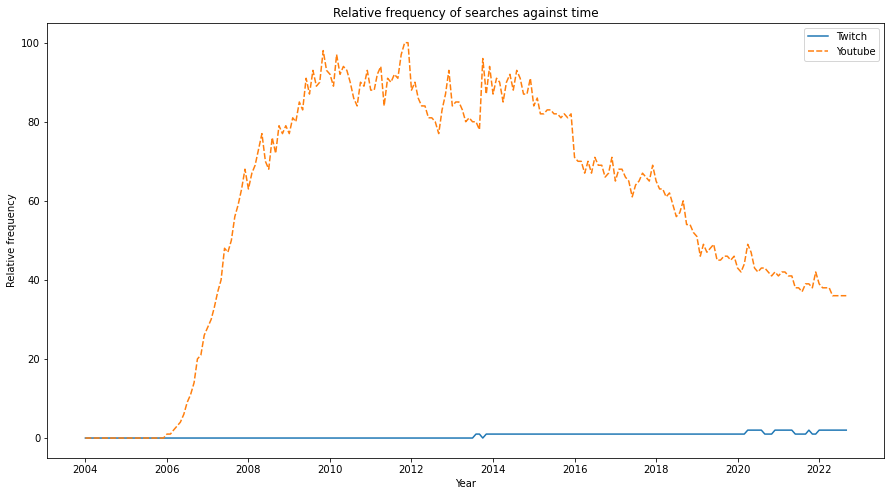

```python
q1all = a_trend
q1all = q1all.set_index('Month', drop=True)
plt.figure(figsize=(15,8))
sns.lineplot(data=q1all)
plt.ylabel('Relative frequency')
plt.xlabel('Year')
plt.title('Relative frequency of searches against time')
plt.show()
```

As we can see from this graph, the relative search frequency of Youtube is many times more than that of Twitch, with a peak at around 2012. However, it appears that the site is on a decline after 2012, save for the sudden rise and fall in middle 2013 and early 2016. The data for Twitch is much too overshadowed by the Youtube data, and we will have to plot a separate graph to get insights.

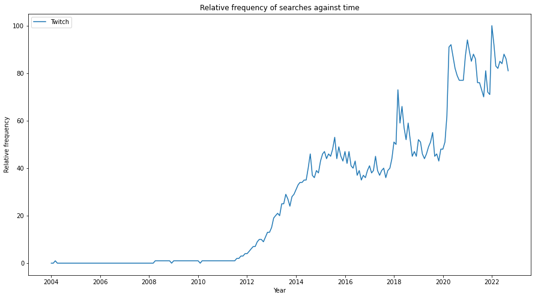

```python
q1t = t_trend
q1t = q1t.set_index('Month', drop=True)
plt.figure(figsize=(15,8))
sns.lineplot(data=q1t)
plt.ylabel('Relative frequency')
plt.xlabel('Year')
plt.title('Relative frequency of searches against time')
plt.show()
```

This graph shows more detail, and shows that from Twitch's inception in 2008 to the middle of 2011, it did not gain much attention. (The data point in early 2004 is anomalous since Twitch had not been created) After the middle of 2011, the site gained massive attention, with the number of searches growing until today.

Another way of answering this question is to take into account the live stream views, since these platforms, more so for Twitch, are reliant of live stream views for their site to grow. If more people were to search for these streams and watch them, this would necessarily mean that the site is more popular.

#### Youtube

We can plot the graph of viewCount against publishing date to get a feel on the trend.

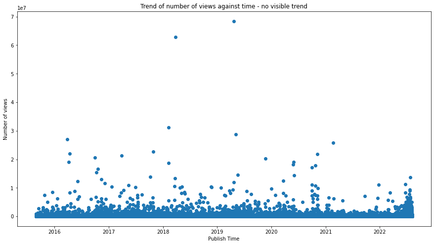

```python
plt.figure(figsize=(15,8))
plt.scatter(yt['publishedAt'], yt['viewCount'])
plt.title('Trend of number of views against time - no visible trend')
plt.xlabel('Publish Time')
plt.ylabel('Number of views')
```

However, there seems to be no significant trend in these livestreams. This could possibly be due to the fact that this sample of data is very skewed toward having low view count. Of note are the few tall spikes corresponding to about 60-70 million views in the middle of the graph. This further illustrates that the distribution of views is skewed toward the right.

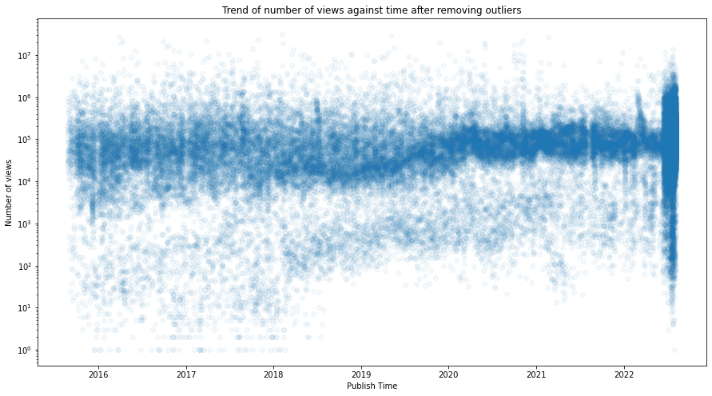

```python
q1yt_data = yt.loc[yt['viewCount'] < 4e7] #remove the 2 outliers
plt.figure(figsize=(15,8))
plt.yscale('log')
plt.scatter(q1yt_data['publishedAt'], q1yt_data['viewCount'], alpha=0.05)
plt.title('Trend of number of views against time after removing outliers')
plt.xlabel('Publish Time')
plt.ylabel('Number of views')
```

After removing the outliers and taking the logarithm of the number of views, there still appears to be no apparent trend for the number of video views against time.

#### Twitch

We can plot the watch time of games against time to quantify the popularity of Twitch, since if more time is spent on watching these games, it would mean that there are more people on the site, making the site popular.

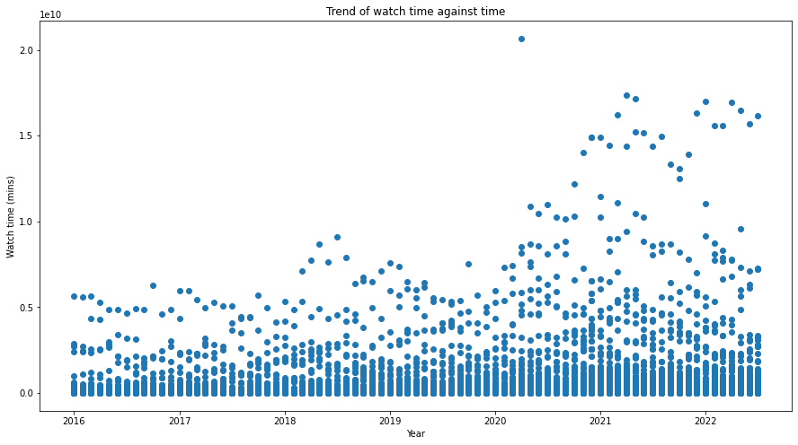

```python
plt.figure(figsize=(15,8))
plt.scatter(t_game['Date'], t_game['Watch time (mins)'])
plt.title('Trend of watch time against time')
plt.xlabel('Year')
plt.ylabel('Watch time (mins)')
```

Although not much can be concluded from this graph yet, as it is still too messy, we can see that the watch time of the top few games has increased after 2020, and there also is an outlier on April 2020, which is the data point for the game Valorant, with a total of around 20 billion minutes of watch time.

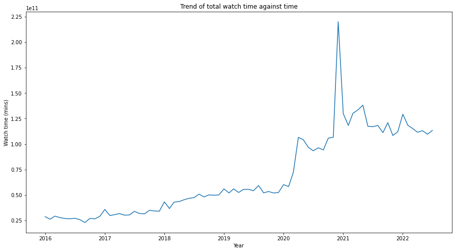

```python
q1sum_t = t_game.groupby('Date')[['Watch time (mins)']].sum()
plt.figure(figsize=(15,8))
plt.plot(q1sum_t.index, q1sum_t['Watch time (mins)'])
plt.title('Trend of total watch time against time')
plt.xlabel('Year')
plt.ylabel('Watch time (mins)')
```

## Q2. How has the distribution of views changed over time?

### Youtube

To get a sense of the distribution of stream views, we can plot a histogram on the frequency of the view count.

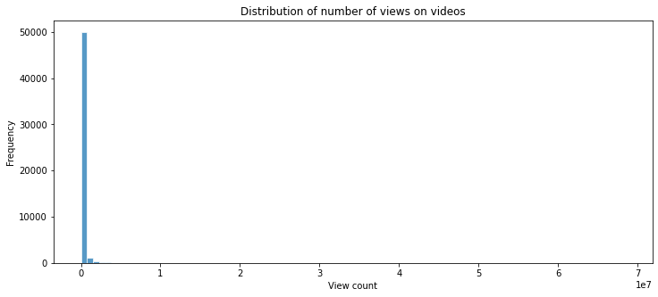

```python
plt.figure(figsize=(12,5))
sns.histplot(yt['viewCount'], bins=90, ec='w')
plt.ylabel('Frequency')
plt.xlabel('View count')
plt.title('Distribution of number of views on videos')
plt.show()
```

This histogram shows that the graph is heavily skewed to the right, and the data point that had ~60-70 million views were just outliers, with much more videos hardly getting any views at all, compared to the outliers. We can separate the data into different years so that we can see the change in this distribution.

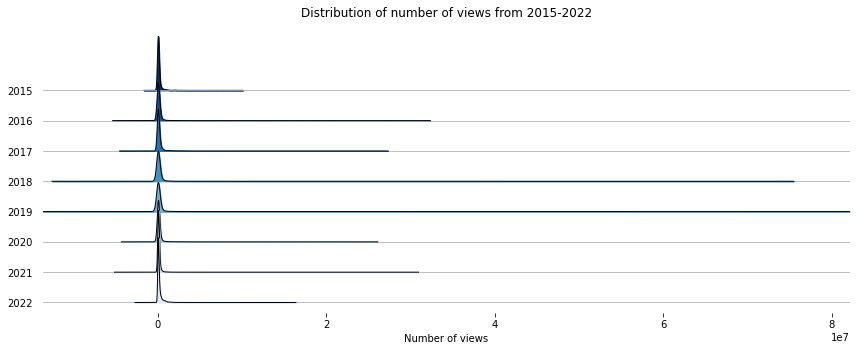

```python
q2joy = yt.copy()
q2joy['Year'] = yt['publishedAt'].dt.year

labels = list(q2joy.Year.unique())
fig, axes = joypy.joyplot(q2joy, by="Year", column="viewCount", labels=labels, range_style='own',
                          grid="y", linewidth=1, legend=False, figsize=(12,5),
                          title="Distribution of number of views from 2015-2022",
                          colormap=cm.Blues_r)
plt.xlabel('Number of views')
```

We can clearly see that the data is skewed much toward the right. We can set limits on the x axis so that we are able to see the distribution clustered around 0 clearer.

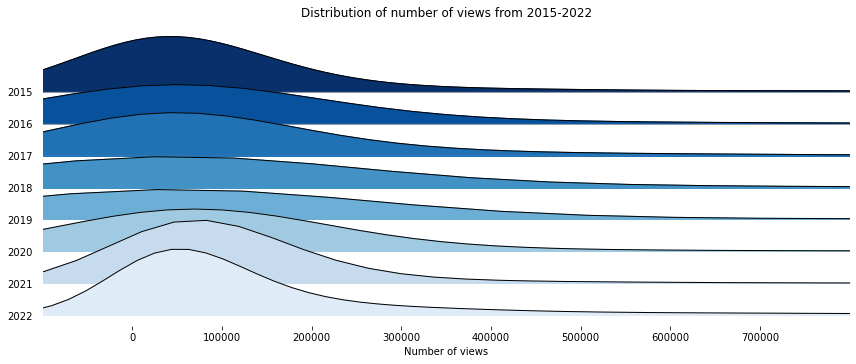

```python
fig, axes = joypy.joyplot(q2joy, by="Year", column="viewCount", labels=labels, range_style='own',
                          grid="y", linewidth=1, legend=False, figsize=(12,5),
                          title="Distribution of number of views from 2015-2022",
                          colormap=cm.Blues_r, x_range=[-1e5,8e5])
plt.xlabel('Number of views')
```

We can clearly see now that the distribution of the number of views became more spread out in 2018 and 2019, but this may be attributed to the outliers as seen on the previous graph.

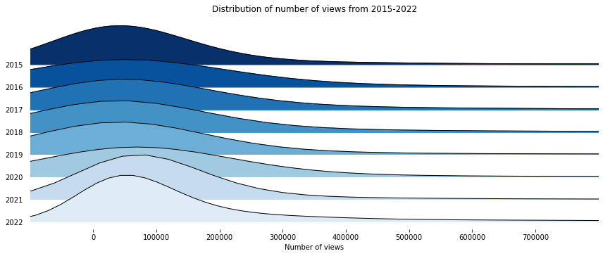

```python
q2filter = q2joy.loc[yt['viewCount'] < 4e7]
fig, axes = joypy.joyplot(q2filter, by="Year", column="viewCount", labels=labels, range_style='own',
                          grid="y", linewidth=1, legend=False, figsize=(12,5),
                          title="Distribution of number of views from 2015-2022",
                          colormap=cm.Blues_r, x_range=[-1e5,8e5])
plt.xlabel('Number of views')
```

### Twitch

The data for the streamers only takes the top 5100 streamers, but we can still plot the number of views gained for them against time for the distribution.

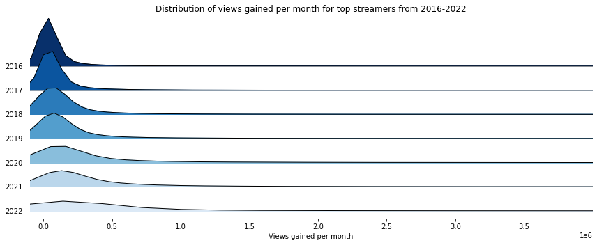

```python
q2twitch = t_streamer.copy()
q2twitch['Year'] = q2twitch['Date'].dt.year
labels = list(q2twitch.Year.unique())

fig, axes = joypy.joyplot(q2twitch, by="Year", column="Views gained", labels=labels, range_style='own',
                          grid="y", linewidth=1, legend=False, figsize=(12,5),
                          title="Distribution of views gained per month for top streamers from 2016-2022",
                          colormap=cm.Blues_r, x_range=[-1e5,4e6])
plt.xlabel('Views gained per month')
```

## Q3. How has the proportion of gaming content changed for each site?

For streamers and corporations interested in gaming on these live streaming sites, it would be important to know about the proportion of gaming content on each site so that they get to know their audience well.

### Youtube

To analyse the proportion of gaming content, we can analyse the categories each live stream falls into.

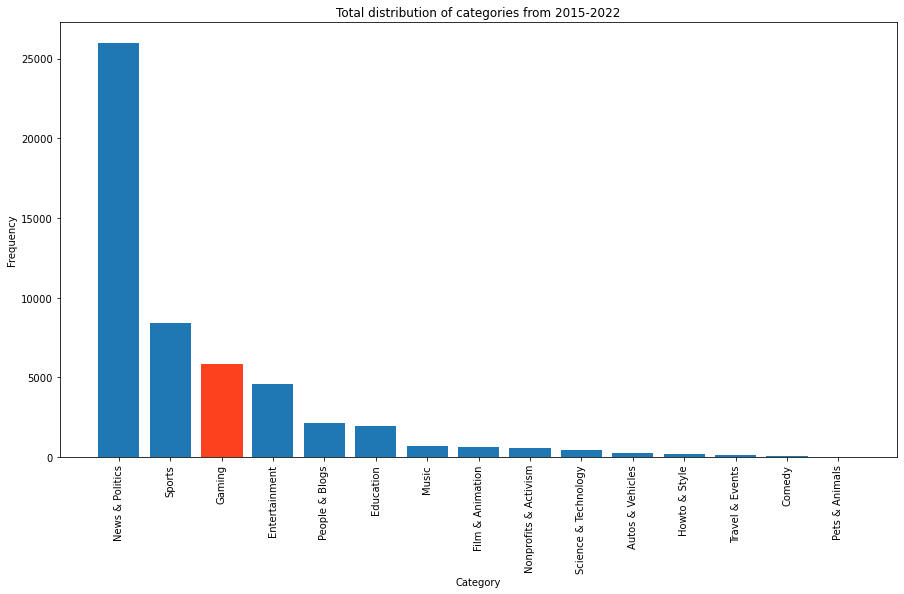

```python
q3total = yt.copy()
plt.figure(figsize=(15,8))
barlist = plt.bar(q3total['category'].value_counts().index,q3total['category'].value_counts())
plt.xticks(rotation = 90)
plt.ylabel('Frequency')
plt.xlabel('Category')
plt.title('Total distribution of categories from 2015-2022')
barlist[2].set_color('xkcd:orange red')
plt.show()
```

We want to see the trend against time, so we will plot an area chart for this.

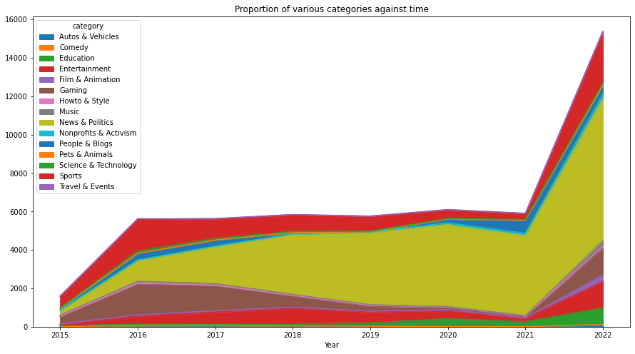

```python
q3time = yt.copy()
q3time['Year'] = q3time['publishedAt'].dt.year
area = q3time.groupby(['Year', 'category']).size().unstack(level=1)
area = area.fillna(0)
area.plot(kind='area', figsize=(15,8))
plt.title('Proportion of various categories against time')
```

There is too much clutter in this area chart. We can simplify by summarising the small sections of the chart into a section of 'Other'. We would also want the proportion, so making the chart out of percentage may be a better choice.

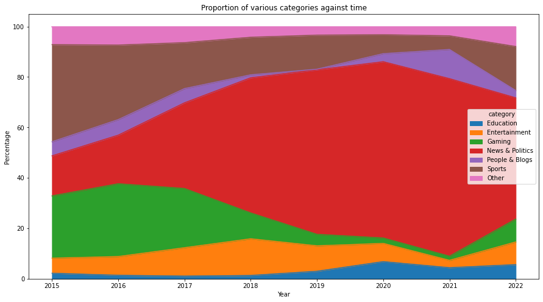

```python
#filter out small parts into 'other'
thres_p = 2.8
thres = area.loc[2022].sum() * thres_p / 100.0
temp = area.T
cols = temp.loc[temp[2022] < thres]
other = area[cols.T.columns].T.sum()
area['Other'] = other
area = area.drop(cols.T.columns, axis=1)

#make area chart based on percentage
area = area.divide(area.sum(axis=1), axis=0)*100
area.plot(kind='area', figsize=(15,8))
plt.ylabel('Percentage')
plt.title('Proportion of various categories against time')
```

### Twitch

To classify Twitch, we can go according to their game data and the website, which classifies each category of streams into larger categories, like 'IRL' and 'Creative'. We can use this to find out these proportions.

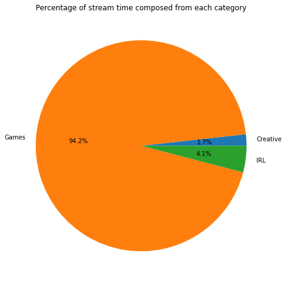

```python
IRL = ['Just Chatting', 'Pools, Hot Tubs and Beaches', 'ASMR', 'Talk Shows & Podcasts', 'Travel & Outdoors', 'Sports',
      'Special Events', 'Animals, Aquariums & Zoos', 'Science & Technology', 'Politics', 'Fitness & Health']
Creative = ['Music', 'Art', 'Makers & Crafting', 'Food & Drink', 'Software & Game Development', 'Beauty & Body Art']

#sorts each 'game' into a category (not everything in 'Game' is a proper game)
def classify(row):
    if row.Game in IRL:
        return 'IRL'
    if row.Game in Creative:
        return 'Creative'
    return 'Games'

q3twitch = t_game.copy()
q3twitch['category'] = q3twitch.apply(classify, axis='columns')

#plot total pie
q3pie = q3twitch.groupby('category')['Stream time (mins)'].sum()
plt.figure(figsize = (15,8))
plt.pie(q3pie, labels=q3pie.index, autopct='%1.1f%%')
plt.title('Percentage of stream time composed from each category')
plt.show()
```

We can see that games take up a large percentage of stream time - 94.2%, while other non-stream content like chatting, done in real life (IRL) take up 4.1% of the total, and creative content like making art takes 1.7%.

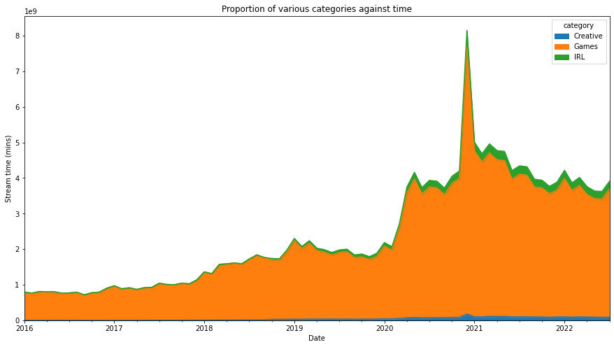

```python
twitch_area = q3twitch.groupby(['Date', 'category'])['Stream time (mins)'].sum().unstack(level=1)

twitch_area.plot(kind='area', figsize=(15,8))
plt.ylabel('Stream time (mins)')
plt.title('Proportion of various categories against time')
```

Like for Youtube, we can create an area chart for the percentages instead.

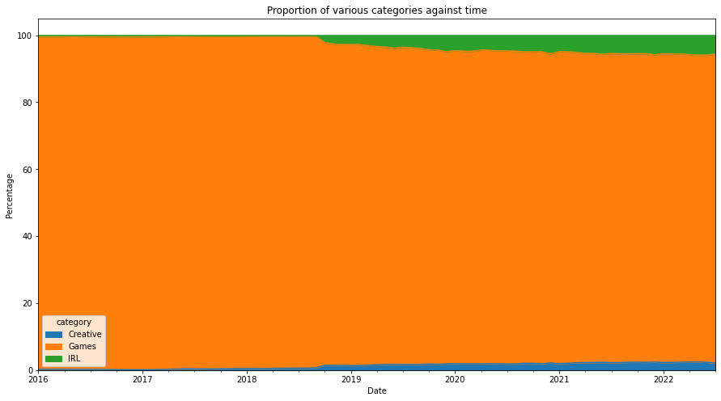

```python
twitch_area = twitch_area.divide(twitch_area.sum(axis=1), axis=0)*100
twitch_area.plot(kind='area', figsize=(15,8))
plt.ylabel('Percentage')
plt.title('Proportion of various categories against time')
```

## Q4. What are the top few games on each platform, and how has their stream time changed?

For any streamer about to hop onto these platforms, it would be important to know what are the top games on the platform itself, and how has their popularity changed so that they can cash in on these trends and get views.

### Youtube

We can find the top few games on each platform by finding out which game has had the most streams.

[output not shown]

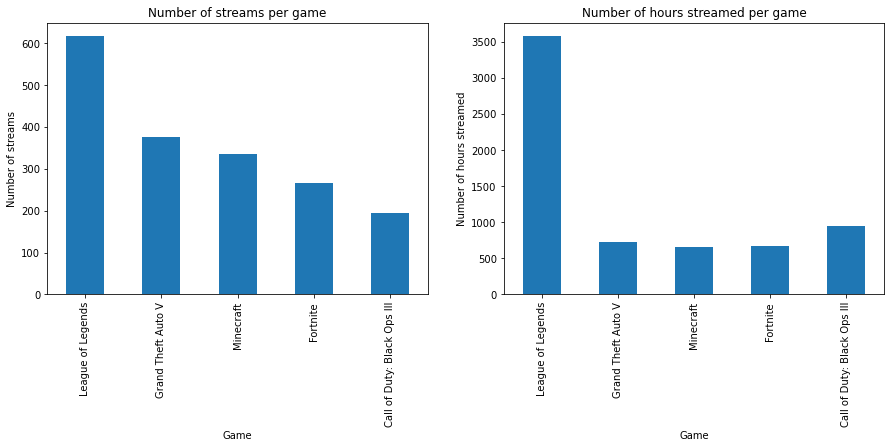

```python
q4yt = yt.copy()
#get all streams with the top 10 games
q4yt = q4yt.loc[q4yt.category == 'Gaming']
q4yt_top10 = q4yt.groupby('game_name').categoryId.count().sort_values(ascending=False)[:5]
q4ytdf10 = q4yt.loc[q4yt['game_name'].isin(q4yt_top10.index)]

#find out stream time (actualEndTime-actualStartTime)
q4ytdf10['duration'] = q4ytdf10['actualEndTime'] - q4ytdf10['actualStartTime']

#filter out erroneous data (stream time too long)
q4ytdf10 = q4ytdf10.drop(q4ytdf10.loc[q4ytdf10.duration > dt.timedelta(hours=200)].index)

q4yttime = q4ytdf10.groupby('game_name').duration.sum()

#plot
fig = plt.figure()

ax0 = fig.add_subplot(1, 2, 1)
ax1 = fig.add_subplot(1, 2, 2)

q4yt_top10.plot(kind='bar', figsize=(15,5), ax=ax0)
ax0.set_title('Number of streams per game')
ax0.set_ylabel('Number of streams')
ax0.set_xlabel('Game')


q4yttime = (q4yttime.dt.total_seconds()/3600)
q4yttime = q4yttime[['League of Legends', 'Grand Theft Auto V', 'Minecraft', 'Fortnite', 'Call of Duty: Black Ops III']]
q4yttime.plot(kind='bar', figsize=(15,5), ax=ax1)
ax1.set_title('Number of hours streamed per game')
ax1.set_ylabel('Number of hours streamed')
ax1.set_xlabel('Game')
```

We can see that League of Legends is the most popular game on Youtube by far on both metrics, since there are an upward of 600 streams and over 3500 hours of stream content. The other 4 games all have between 200-400 streams in total, and all have nearly the same amount of content - 600-900 hours of it.

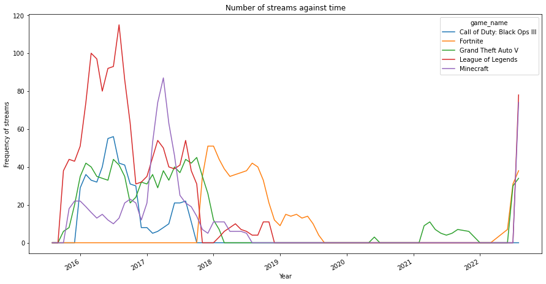

```python
#normalise the publishAt time to the start of the month
q4ytdf10['month'] = q4ytdf10['publishedAt'].to_numpy().astype('datetime64[M]')

#grouping
q4ytmonth10 = q4ytdf10.groupby(['month', 'game_name']).size().unstack(level=1)

#smoothing
for col in q4ytmonth10.columns:
    q4ytmonth10[col] = q4ytmonth10[col].rolling(3).sum()

#plotting
q4ytmonth10 = q4ytmonth10.fillna(0)
q4ytmonth10.plot(kind='line', figsize=(15, 8))
plt.title('Number of streams against time')
plt.xlabel('Year')
plt.ylabel('Frequency of streams')
plt.show()
```

From here, we can see that from August 2015 to around 2019, the frequency of streams was quite high, with League of Legends getting the most streams overall at around 115 in around July 2016. However, these games fell out of popularity after 2019, only to spike back up in July 2022. A small exception would be Fortnite, which got a late start on September 2017, but still fell off in time at August 2019, again spiking back in July 2022.

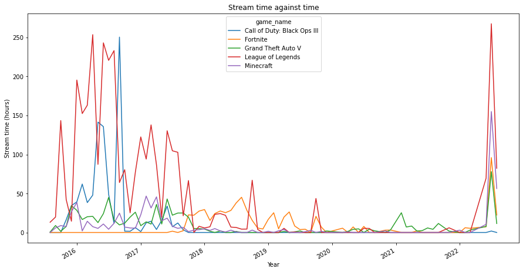

```python
q4ytmonthtime10 = q4ytdf10.groupby(['month', 'game_name']).duration.sum()
q4ytmonthtime10 = (q4ytmonthtime10.dt.total_seconds()/3600)
q4ytmonthtime10 = q4ytmonthtime10.unstack(level=1)
q4ytmonthtime10 = q4ytmonthtime10.fillna(0)

q4ytmonthtime10.plot(kind='line', figsize=(15, 8))
plt.title('Stream time against time')
plt.xlabel('Year')
plt.ylabel('Stream time (hours)')
plt.show()
```

This graph shows the total stream time for each game, showing the jump in the stream time in the middle of 2022, and the decrease from 2017 to 2019. However, this graph is too noisy and has to be smoothened.

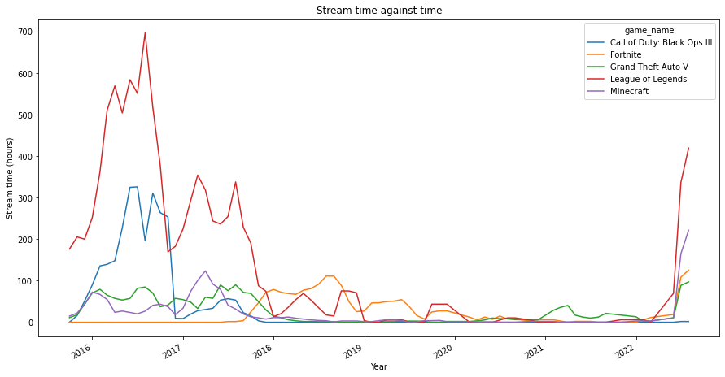

```python
#smoothing
for col in q4ytmonthtime10.columns:
    q4ytmonthtime10[col] = q4ytmonthtime10[col].rolling(3).sum()

q4ytmonthtime10.plot(kind='line', figsize=(15, 8))
plt.title('Stream time against time')
plt.xlabel('Year')
plt.ylabel('Stream time (hours)')
plt.show()
```

Now we can see the stream time better, again League of Legends showing the same spike in September 2016 and the recent spike in stream time, which more or less lines up with the stream frequency.

### Twitch

For Twitch, we can take the top few games recently and plot a line chart on their stream time.

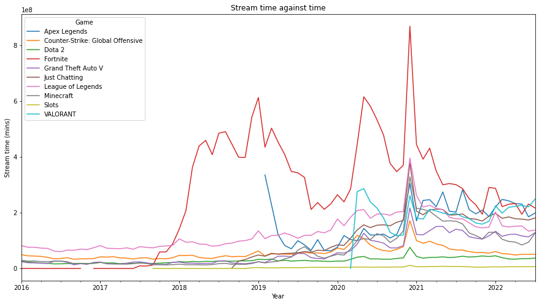

```python
q4twitch = t_game.copy()
q4twitch10 = q4twitch.loc[(q4twitch.Date == '2022-07-01') & (q4twitch.ranking <= 10)].Game
q4tdf10 = q4twitch.loc[q4twitch.Game.isin(q4twitch10)]
q4tmonth10 = q4tdf10.groupby(['Game', 'Date'])['Stream time (mins)'].sum()
q4tmonth10 = q4tmonth10.unstack(level=1)
q4tmonth10.fillna(0)
q4tmonth10 = q4tmonth10.T
q4tmonth10.plot(kind='line', figsize=(15,8))
plt.xlabel('Year')
plt.ylabel('Stream time (mins)')
plt.title('Stream time against time')
plt.show()
```

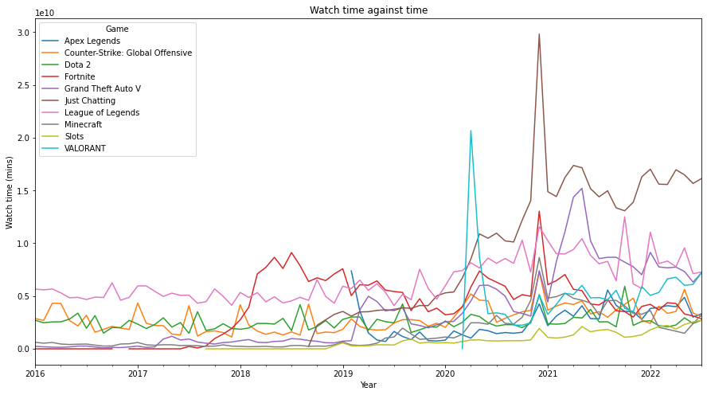

```python
q4twatch10 = q4tdf10.groupby(['Game', 'Date'])['Watch time (mins)'].sum()
q4twatch10 = q4twatch10.unstack(level=1)
q4twatch10.fillna(0)
q4twatch10 = q4twatch10.T
q4twatch10.plot(kind='line', figsize=(15,8))
plt.xlabel('Year')
plt.ylabel('Watch time (mins)')
plt.title('Watch time against time')
plt.show()
```

This graph shows the watch time for these games. This graph tells a different story than the graph of stream time. Instead, the category of 'Just Chatting' has the most watch time, with a peak of 3e10 minutes of watch time in total in December 2020. In spite of this, the graph still shows the same spikes, with the spike in December 2020 and the jump in April 2020. For the jump in April 2020, it appears that VALORANT has the biggest spike up to 2.1e10 viewers in April 2020.

## Q5. What is the relationship between the stream time and the number of followers gained for Twitch streamers?

Since Twitch has much more game content than Youtube, it would be more likely that any random streamer chosen from the dataset would be involved in streaming games. It would then be appropriate for game streamers looking into Twitch to look into how much stream time it would take to gain followers to judge whether Twitch is the best platform for them.

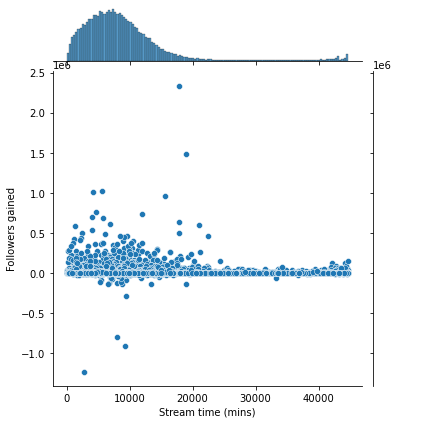

```python
q5twitch = t_streamer.copy().sample(n=50000)

sns.jointplot(x=q5twitch['Stream time (mins)'], y=q5twitch['Followers gained'], data=q5twitch)
```

From this jointplot, we can see that most of the points are clustered along the line y=0, but that may be because of the high fluctuations in the followers gained when the stream time is between 0-20000 minutes. The distribution of stream time is skewed toward the right in a weak bimodal distribution, with a few outliers clustering at a stream time of 40000-45000 minutes.

```python
#filter outliers
q5twitch = q5twitch.loc[q5twitch['Stream time (mins)'] < 38000]

lm = LinearRegression()
X_train, X_test, y_train, y_test = train_test_split(q5twitch[['Stream time (mins)']], q5twitch['Followers gained'], test_size=0.2, random_state=0)
lm.fit(X_train, y_train)
print(lm.intercept_)
print(lm.coef_)
```

```
6240.731789363734
[-0.05290382]
```

The coefficient is very slightly negative, so we can expect less followers gained with more stream time.

```python
yhat = lm.predict(X_test)
yhat
```

```
array([6186.76989285, 6074.87831333, 5892.36013395, ..., 5908.23127999,
       5846.33381046, 5784.43634093])
```

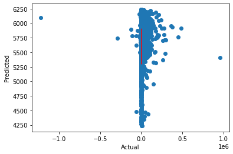

```python
plt.scatter(y_test, yhat)
plt.plot([5300,5900], [5300,5900], color="red")
plt.xlabel('Actual')
plt.ylabel('Predicted')
```

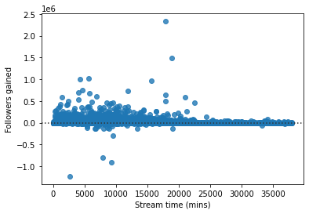

```python
sns.residplot(x=q5twitch[['Stream time (mins)']], y=q5twitch['Followers gained'])
```

```python
lm.score(X_train, y_train)
```

```
9.912513583021365e-05
```

However, after looking at the residual plot, the plot of actual vs predicted data, and the R^2 value of this fit being very close to 0, we can see that the spread of points in the portion of 0-20000 minutes of stream time is too erratic and this linear regression is not a good fit.

# Results Findings & Conclusion

### Q1. How has the popularity of these platforms changed over time?

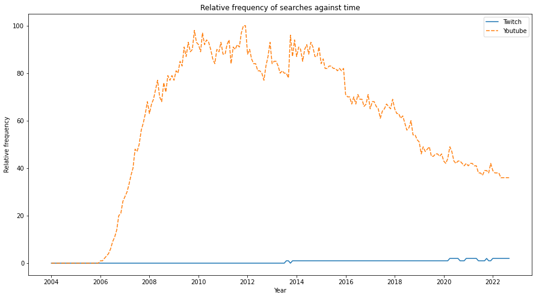

```python
plt.figure(figsize=(15,8))
sns.lineplot(data=q1all)
plt.ylabel('Relative frequency')
plt.xlabel('Year')
plt.title('Relative frequency of searches against time')
plt.show()
```

From this graph, we can see that the number of searches of Youtube on Google are much more than that of Twitch, so the popularity of Youtube is still much more than Twitch. However, the popularity of Youtube is on a decreasing trend, and the popularity of Twitch seems to be increasing.

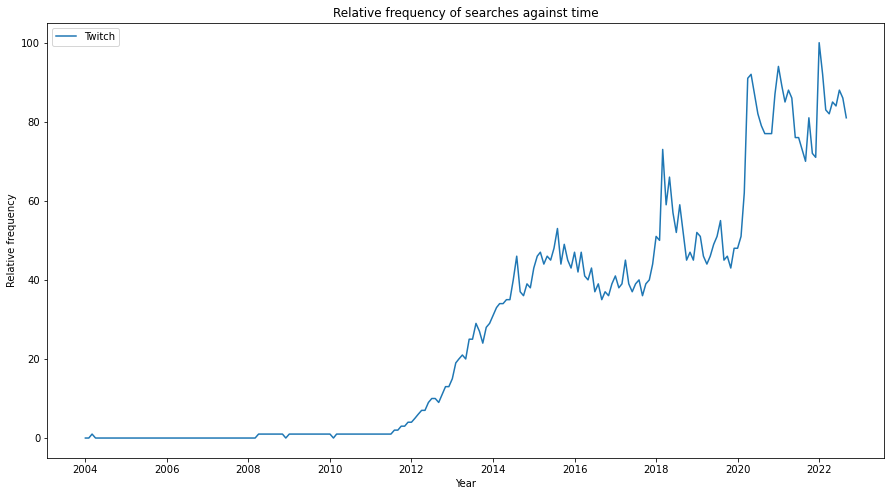

```python
plt.figure(figsize=(15,8))
sns.lineplot(data=q1t)
plt.ylabel('Relative frequency')
plt.xlabel('Year')
plt.title('Relative frequency of searches against time')
plt.show()
```

Since the above graph does not summarise the fine detail of the Twitch trend of searches well, I have plotted this graph, which shows the details better. The popularity of Twitch has skyrocketed in the recet 2 years, especially with a huge jump in April 2020, which can be attributed to the COVID-19 pandemic where many stayed home and found Twitch as a source of entertainment.

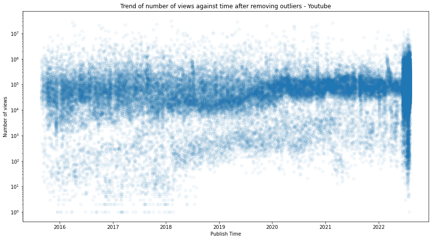

```python
plt.figure(figsize=(15,8))
plt.yscale('log')
plt.scatter(q1yt_data['publishedAt'], q1yt_data['viewCount'], alpha=0.05)
plt.title('Trend of number of views against time after removing outliers - Youtube')
plt.xlabel('Publish Time')
plt.ylabel('Number of views')
```

When we plot the log scale of the number of views on Youtube against the publish time, we get a close to horizontal line at around 10^5 views, and a distribution with high spread around July 2022. This does not show any significant trend.

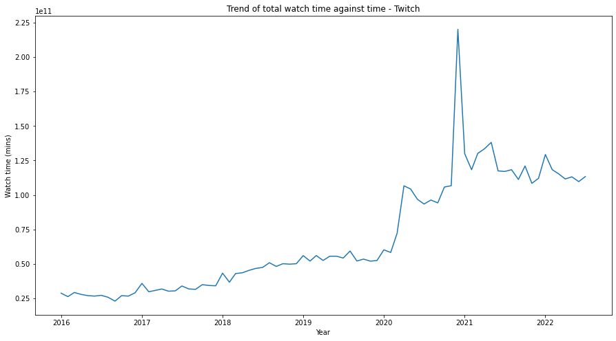

```python
plt.figure(figsize=(15,8))
plt.plot(q1sum_t.index, q1sum_t['Watch time (mins)'])
plt.title('Trend of total watch time against time - Twitch')
plt.xlabel('Year')
plt.ylabel('Watch time (mins)')
```

When we plot the total watch time of Twitch against time, we can see an increasing trend. The spike in April 2020 also appears here, which shows that the popularity of Twitch has spiked during the COVID-19 pandemic. The watch time after that hovers around 1.25e11 views.

### Q2. How has the distribution of views changed over time?

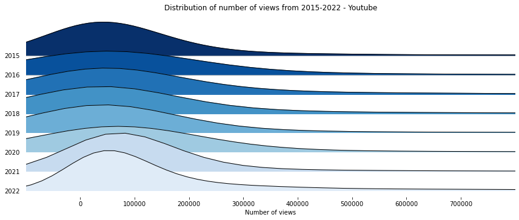

```python
labels = list(q2joy.Year.unique())
fig, axes = joypy.joyplot(q2filter, by="Year", column="viewCount", labels=labels, range_style='own',
                          grid="y", linewidth=1, legend=False, figsize=(12,5),
                          title="Distribution of number of views from 2015-2022 - Youtube",
                          colormap=cm.Blues_r, x_range=[-1e5,8e5])
plt.xlabel('Number of views')
```

We can see that the distribution between 2016-2020 has remained roughly the same, with a mode of around 30000 views per stream. however, in 2021, the distribution became less spread out, and the mode increased to around 80000 views. The cluster got even tighter in 2022 but the mode decreased to 50000 views. This shows that in 2021 and 2022, a livestream can expect to receive around 60000 views, and with less uncertainty than in previous years.

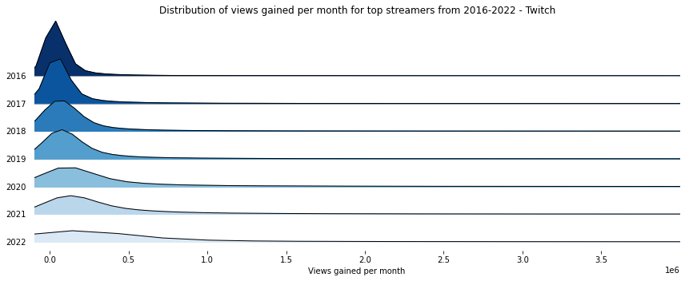

```python
labels = list(q2twitch.Year.unique())

fig, axes = joypy.joyplot(q2twitch, by="Year", column="Views gained", labels=labels, range_style='own',
                          grid="y", linewidth=1, legend=False, figsize=(12,5),
                          title="Distribution of views gained per month for top streamers from 2016-2022 - Twitch",
                          colormap=cm.Blues_r, x_range=[-1e5,4e6])
plt.xlabel('Views gained per month')
```

For the topmost streamers, we can see that the spread of the number of views has been getting wider since 2016, and the mode of the views gained has been slightly increasing, from around 30000 views gained per month to 200000 views gained per month from 2016 to 2022. This shows that top streamers in 2022 can expect to get more views per month, with some getting much more than the mode.

In conclusion, we find that the distribution for the number of views per stream on Youtube is becoming more clustered, with its mode having increased from past years, while the views gained per month for top streamers has its distribution gradually spreading, and the mode of the views gained consistently increasing.